# R Notebook

```r
date() # Current system time and date.
```

```
[1] "Tue Jul 16 08:38:44 2024"
```

```r
Sys.time() # Current system time and date (redundant).
```

```
[1] "2024-07-16 08:38:44 +07"
```

```r
R.version.string # R version and version release date.
```

```
[1] "R version 4.2.3 (2023-03-15 ucrt)"
```

```r
options(digits=6) # Confirm default digits.
options(scipen=999)# Suppress scientific notation.
options(width=60) # Confirm output width.
ls() # List all objects in the working # directory.
```

```
  [1] "age"                  "agecat"
  [3] "agegroup_by_gender"   "b"
  [5] "bmi"                  "bmi_cat"
  [7] "bmicat"               "c"
  [9] "cat_table"            "cat_vars"
 [11] "chol"                 "col"
 [13] "comorbid"             "copd"
 [15] "cor_matrix"           "correlation_matrix"
 [17] "d"                    "db"
 [19] "db_by_hdlcat"         "db_by_hdlcat_prop"
 [21] "db_num"               "dependent_var"
 [23] "dm_by_age"            "dm_by_age_group"
 [25] "dm_by_age_prop"       "dm_by_agegroup_prop"
 [27] "dm_by_bmi"            "dm_by_bmi_cat"
 [29] "dm_by_bmi_cat_prop"   "dm_by_bmi_odds"
```

[output cut: 48 more lines]

```r
rm(list = ls()) # CAUTION: Remove all files in the #working directory. If this action is not desired, use rm() one-by-one to remove the objectsthat are not needed.
ls.str() # List all objects with finite detail.
getwd() # Identify the current working directory
```

```
[1] "C:/Users/linan/Documents/GitHub/project/R-project/using-r-for-biostatistics"
```

```r
setwd("C:/Users/linan/Documents/GitHub/project/R-project/using-r-for-biostatistics") # Set to a new working directory. # Note the single forward slash and double # quotes. # This new directory should be the directory # where the data file is located, otherwise # the data file will not be found.
getwd()# Confirm the working directory.
```

```
[1] "C:/Users/linan/Documents/GitHub/project/R-project/using-r-for-biostatistics"
```

```r
list.files()# List files at the PC directory
```

```
 [1] "assignment.csv"
 [2] "BreedMilkLb365.txt"
 [3] "Chapter-1-Import Files.Rmd"
 [4] "Chapter-2-exploration-visualization.Rmd"
 [5] "Chapter-3-distribution-correlation.nb.html"
 [6] "Chapter-3-distribution-correlation.Rmd"
 [7] "CPIIISectionLbsGender.csv"
 [8] "data-exploration-SBP.html"
 [9] "data-exploration-SBP.Rmd"
[10] "datasets"
[11] "distribution-correlation.pdf"
[12] "EmpWellAge21to79.csv"
[13] "GenderEndurance.csv"
[14] "graphs"
[15] "nhanes_2015_2016.csv"
[16] "Rplot-Frequency of variables.png"
[17] "Rplot - Distribution of factor-type object variables gender, RaceEthnicity, BMIStatus, and obesity.png"
[18] "Rplot - Distribution of numeric-type object variable age.png"
[19] "SmartWayVehicleListMY2008.csv"
[20] "Sorghum2012to2016.xlsx"
[21] "YearSoilTypeCropRainYieldBushelsPerAcreNoHeader.txt"
```

```r
.libPaths()# Library pathname
```

```
[1] "C:/Users/linan/AppData/Local/R/win-library/4.2"
[2] "C:/Program Files/R/R-4.2.3/library"
```

```r
.Library# Library pathname.
```

```
[1] "C:/PROGRA~1/R/R-42~1.3/library"
```

```r
search()# Attached packages and objects.
```

```
 [1] ".GlobalEnv"        "package:beeswarm"
 [3] "package:lubridate" "package:forcats"
 [5] "package:stringr"   "package:purrr"
 [7] "package:readr"     "package:tidyr"
 [9] "package:tibble"    "package:tidyverse"
[11] "package:ggplot2"   "package:gmodels"
[13] "package:Hmisc"     "package:dplyr"
[15] "tools:rstudio"     "package:stats"
[17] "package:graphics"  "package:grDevices"
[19] "package:utils"     "package:datasets"
[21] "package:methods"   "Autoloads"
[23] "package:base"
```

```r
searchpaths() # Attached packages and objects.
```

```
 [1] ".GlobalEnv"
 [2] "C:/Users/linan/AppData/Local/R/win-library/4.2/beeswarm"
 [3] "C:/Users/linan/AppData/Local/R/win-library/4.2/lubridate"
 [4] "C:/Users/linan/AppData/Local/R/win-library/4.2/forcats"
 [5] "C:/Users/linan/AppData/Local/R/win-library/4.2/stringr"
 [6] "C:/Users/linan/AppData/Local/R/win-library/4.2/purrr"
 [7] "C:/Users/linan/AppData/Local/R/win-library/4.2/readr"
 [8] "C:/Users/linan/AppData/Local/R/win-library/4.2/tidyr"
 [9] "C:/Users/linan/AppData/Local/R/win-library/4.2/tibble"
[10] "C:/Users/linan/AppData/Local/R/win-library/4.2/tidyverse"
[11] "C:/Users/linan/AppData/Local/R/win-library/4.2/ggplot2"
[12] "C:/Users/linan/AppData/Local/R/win-library/4.2/gmodels"
[13] "C:/Users/linan/AppData/Local/R/win-library/4.2/Hmisc"
[14] "C:/Users/linan/AppData/Local/R/win-library/4.2/dplyr"
[15] "tools:rstudio"
[16] "C:/Program Files/R/R-4.2.3/library/stats"
[17] "C:/Program Files/R/R-4.2.3/library/graphics"
[18] "C:/Program Files/R/R-4.2.3/library/grDevices"
[19] "C:/Program Files/R/R-4.2.3/library/utils"
[20] "C:/Program Files/R/R-4.2.3/library/datasets"
[21] "C:/Program Files/R/R-4.2.3/library/methods"
[22] "Autoloads"
[23] "C:/PROGRA~1/R/R-42~1.3/library/base"
```

```r
###############################################################
```

```r
library(dplyr)
library(Hmisc)
library(gmodels)
library(ggplot2)
library(tidyverse)
library(beeswarm)
```

```r
setwd("C:/Users/linan/Documents/GitHub/project/R-project/using-r-for-biostatistics")
```

```r
EmployeeBiometric.df <- read.table(file="EmpWellAge21to79.csv", header=TRUE, dec=".", sep = ",")
```

```r
str(EmployeeBiometric.df)
```

```
'data.frame':   3945 obs. of  10 variables:
 $ EmployeeID          : chr  "ID10005" "ID10010" "ID10016" "ID10028" ...
 $ Gender              : int  1 1 1 2 1 1 1 2 1 1 ...
 $ AgeYears            : int  34 67 41 57 35 40 40 34 40 50 ...
 $ RaceEthnicity       : int  5 5 5 1 5 3 2 5 2 2 ...
 $ TotalCholesterolmgdL: int  221 175 224 217 139 198 NA 205 87 149 ...
 $ SBPmmHg             : int  102 NA NA 90 86 114 NA 92 120 126 ...
 $ DBPmmHg             : int  44 NA NA 42 42 74 NA 48 80 72 ...
 $ BMIMetric           : num  18.4 18.7 21.6 20.6 18.7 ...
 $ BMIStatus           : int  1 2 2 2 2 2 2 2 1 2 ...
 $ Obesity             : int  1 1 1 1 1 1 1 1 1 1 ...
```

```r
dim(EmployeeBiometric.df)
```

```
[1] 3945   10
```

```r
head(EmployeeBiometric.df)
```

|  | EmployeeID | Gender | AgeYears | RaceEthnicity | TotalCholesterolmgdL | SBPmmHg | DBPmmHg | BMIMetric | BMIStatus | Obesity |
| --- | --- | --- | --- | --- | --- | --- | --- | --- | --- | --- |
| 1 | ID10005 | 1 | 34 | 5 | 221 | 102 | 44 | 18.35 | 1 | 1 |
| 2 | ID10010 | 1 | 67 | 5 | 175 | NA | NA | 18.66 | 2 | 1 |
| 3 | ID10016 | 1 | 41 | 5 | 224 | NA | NA | 21.61 | 2 | 1 |
| 4 | ID10028 | 2 | 57 | 1 | 217 | 90 | 42 | 20.59 | 2 | 1 |
| 5 | ID10041 | 1 | 35 | 5 | 139 | 86 | 42 | 18.66 | 2 | 1 |
| 6 | ID10051 | 1 | 40 | 3 | 198 | 114 | 74 | 19.73 | 2 | 1 |

Check for duplicate in individual level = no duplicate ID

```r
table(duplicated(EmployeeBiometric.df$EmployeeID))
```

```
FALSE
 3945
```

```r
summary(EmployeeBiometric.df)
```

```
  EmployeeID            Gender        AgeYears    RaceEthnicity TotalCholesterolmgdL    SBPmmHg       DBPmmHg        BMIMetric      BMIStatus       Obesity
 Length:3945        Min.   :1.00   Min.   :21.0   Min.   :1.0   Min.   : 78          Min.   : 74   Min.   : 34.0   Min.   :13.4   Min.   :1.00   Min.   :1.00
 Class :character   1st Qu.:1.00   1st Qu.:34.0   1st Qu.:2.0   1st Qu.:151          1st Qu.:108   1st Qu.: 60.0   1st Qu.:22.6   1st Qu.:2.00   1st Qu.:1.00
 Mode  :character   Median :1.00   Median :47.0   Median :3.0   Median :175          Median :118   Median : 70.0   Median :26.4   Median :3.00   Median :1.00
                    Mean   :1.47   Mean   :47.7   Mean   :3.4   Mean   :180          Mean   :122   Mean   : 69.3   Mean   :27.7   Mean   :2.86   Mean   :1.31
                    3rd Qu.:2.00   3rd Qu.:61.0   3rd Qu.:5.0   3rd Qu.:205          3rd Qu.:132   3rd Qu.: 78.0   3rd Qu.:31.3   3rd Qu.:4.00   3rd Qu.:2.00
                    Max.   :2.00   Max.   :79.0   Max.   :5.0   Max.   :380          Max.   :222   Max.   :122.0   Max.   :70.1   Max.   :4.00   Max.   :2.00
                                                                NA's   :894          NA's   :209   NA's   :217     NA's   :20     NA's   :20     NA's   :20
```

##Change EmployeeID,Gender, Ethnic, and BMIStatus from int to factor

```r
EmployeeBiometric.df$EmployeeID <- as.factor(EmployeeBiometric.df$EmployeeID)
```

```r
EmployeeBiometric.df$Gender <- factor(EmployeeBiometric.df$Gender,
                                      labels=c("Female","Male"))
levels(EmployeeBiometric.df$Gender)
```

```
[1] "Female" "Male"
```

```r
EmployeeBiometric.df$BMIStatus<-factor(EmployeeBiometric.df$BMIStatus,
                                       labels = c("Underweight","Normal Weight", "Overweight","Obese"))
levels(EmployeeBiometric.df$BMIStatus)
```

```
[1] "Underweight"   "Normal Weight" "Overweight"    "Obese"
```

```r
EmployeeBiometric.df$RaceEthnicity <-
  factor(EmployeeBiometric.df$RaceEthnicity,
         labels=c("Asian","Black","Hispanic","Other","White"))
levels(EmployeeBiometric.df$RaceEthnicity)
```

```
[1] "Asian"    "Black"    "Hispanic" "Other"    "White"
```

```r
EmployeeBiometric.df$Obesity <-
  factor(EmployeeBiometric.df$Obesity,
         labels=c("Not Obese","Obese"))
levels(EmployeeBiometric.df$Obesity)
```

```
[1] "Not Obese" "Obese"
```

Change AgeYears, SBPmmHg, DBPmmHg from int to numeric

```r
EmployeeBiometric.df$AgeYears <- as.numeric(EmployeeBiometric.df$AgeYears)
EmployeeBiometric.df$SBPmmHg <- as.numeric(EmployeeBiometric.df$SBPmmHg)
EmployeeBiometric.df$DBPmmHg <- as.numeric(EmployeeBiometric.df$DBPmmHg)
```

Check data structure

```r
str(EmployeeBiometric.df)
```

```
'data.frame':   3945 obs. of  10 variables:
 $ EmployeeID          : Factor w/ 3945 levels "ID10005","ID10010",..: 1 2 3 4 5 6 7 8 9 10 ...
 $ Gender              : Factor w/ 2 levels "Female","Male": 1 1 1 2 1 1 1 2 1 1 ...
 $ AgeYears            : num  34 67 41 57 35 40 40 34 40 50 ...
 $ RaceEthnicity       : Factor w/ 5 levels "Asian","Black",..: 5 5 5 1 5 3 2 5 2 2 ...
 $ TotalCholesterolmgdL: int  221 175 224 217 139 198 NA 205 87 149 ...
 $ SBPmmHg             : num  102 NA NA 90 86 114 NA 92 120 126 ...
 $ DBPmmHg             : num  44 NA NA 42 42 74 NA 48 80 72 ...
 $ BMIMetric           : num  18.4 18.7 21.6 20.6 18.7 ...
 $ BMIStatus           : Factor w/ 4 levels "Underweight",..: 1 2 2 2 2 2 2 2 1 2 ...
 $ Obesity             : Factor w/ 2 levels "Not Obese","Obese": 1 1 1 1 1 1 1 1 1 1 ...
```

```r
getwd()
```

```
[1] "C:/Users/linan/Documents/GitHub/project/R-project/using-r-for-biostatistics"
```

```r
ls()
```

```
[1] "EmployeeBiometric.df"
```

```r
attach(EmployeeBiometric.df)
dim(EmployeeBiometric.df)
```

```
[1] 3945   10
```

```r
names(EmployeeBiometric.df)
```

```
 [1] "EmployeeID"           "Gender"               "AgeYears"             "RaceEthnicity"        "TotalCholesterolmgdL" "SBPmmHg"              "DBPmmHg"              "BMIMetric"
 [9] "BMIStatus"            "Obesity"
```

```r
colnames(EmployeeBiometric.df)
```

```
 [1] "EmployeeID"           "Gender"               "AgeYears"             "RaceEthnicity"        "TotalCholesterolmgdL" "SBPmmHg"              "DBPmmHg"              "BMIMetric"
 [9] "BMIStatus"            "Obesity"
```

```r
head(EmployeeBiometric.df)
```

|  | EmployeeID | Gender | AgeYears | RaceEthnicity | TotalCholesterolmgdL | SBPmmHg | DBPmmHg | BMIMetric | BMIStatus | Obesity |
| --- | --- | --- | --- | --- | --- | --- | --- | --- | --- | --- |
| 1 | ID10005 | Female | 34 | White | 221 | 102 | 44 | 18.35 | Underweight | Not Obese |
| 2 | ID10010 | Female | 67 | White | 175 | NA | NA | 18.66 | Normal Weight | Not Obese |
| 3 | ID10016 | Female | 41 | White | 224 | NA | NA | 21.61 | Normal Weight | Not Obese |
| 4 | ID10028 | Male | 57 | Asian | 217 | 90 | 42 | 20.59 | Normal Weight | Not Obese |
| 5 | ID10041 | Female | 35 | White | 139 | 86 | 42 | 18.66 | Normal Weight | Not Obese |
| 6 | ID10051 | Female | 40 | Hispanic | 198 | 114 | 74 | 19.73 | Normal Weight | Not Obese |

```r
tail(EmployeeBiometric.df)
```

|  | EmployeeID | Gender | AgeYears | RaceEthnicity | TotalCholesterolmgdL | SBPmmHg | DBPmmHg | BMIMetric | BMIStatus | Obesity |
| --- | --- | --- | --- | --- | --- | --- | --- | --- | --- | --- |
| 3940 | ID50080 | Male | 57 | White | 152 | 98 | 62 | NA | NA | NA |
| 3941 | ID50087 | Female | 44 | Asian | NA | 108 | 64 | NA | NA | NA |
| 3942 | ID50104 | Male | 45 | Asian | NA | 138 | 74 | NA | NA | NA |
| 3943 | ID50108 | Female | 28 | Hispanic | 186 | 156 | 88 | NA | NA | NA |
| 3944 | ID50109 | Female | 57 | White | 139 | NA | NA | NA | NA | NA |
| 3945 | ID50126 | Male | 57 | White | 170 | NA | NA | NA | NA | NA |

```r
summary(EmployeeBiometric.df)
```

```
   EmployeeID      Gender        AgeYears     RaceEthnicity  TotalCholesterolmgdL    SBPmmHg       DBPmmHg        BMIMetric            BMIStatus         Obesity
 ID10005:   1   Female:2078   Min.   :21.0   Asian   : 482   Min.   : 78          Min.   : 74   Min.   : 34.0   Min.   :13.4   Underweight  : 168   Not Obese:2719
 ID10010:   1   Male  :1867   1st Qu.:34.0   Black   : 818   1st Qu.:151          1st Qu.:108   1st Qu.: 60.0   1st Qu.:22.6   Normal Weight:1437   Obese    :1206
 ID10016:   1                 Median :47.0   Hispanic: 904   Median :175          Median :118   Median : 70.0   Median :26.4   Overweight   :1114   NA's     :  20
 ID10028:   1                 Mean   :47.7   Other   : 117   Mean   :180          Mean   :122   Mean   : 69.3   Mean   :27.7   Obese        :1206
 ID10041:   1                 3rd Qu.:61.0   White   :1624   3rd Qu.:205          3rd Qu.:132   3rd Qu.: 78.0   3rd Qu.:31.3   NA's         :  20
 ID10051:   1                 Max.   :79.0                   Max.   :380          Max.   :222   Max.   :122.0   Max.   :70.1
 (Other):3939                                                NA's   :894          NA's   :209   NA's   :217     NA's   :20
```

Conduct a Visual Data Check Using Graphics using epiDisplay

Create bar plots for factor variables : Gender, RaceEthnicity, BMIStatus, Obesity

```
EmployeeBiometric.df$Gender :
        Frequency Percent Cum. percent
Female       2078    52.7         52.7
Male         1867    47.3        100.0
  Total      3945   100.0        100.0
```

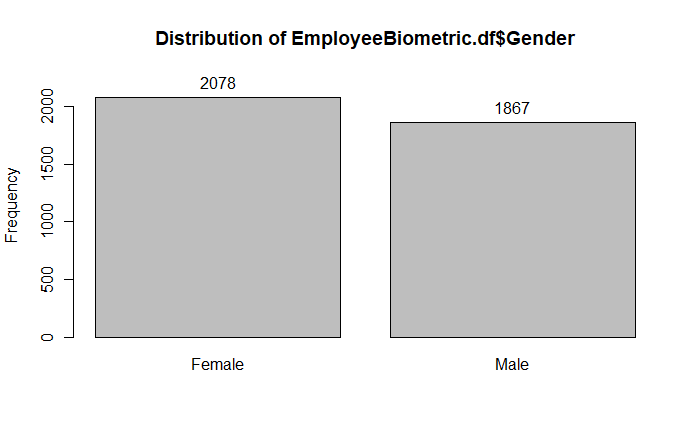

```r
epiDisplay::tab1(EmployeeBiometric.df$Gender)
```

```
EmployeeBiometric.df$RaceEthnicity :
         Frequency Percent Cum. percent
Asian          482    12.2         12.2
Black          818    20.7         33.0
Hispanic       904    22.9         55.9
Other          117     3.0         58.8
White         1624    41.2        100.0
  Total       3945   100.0        100.0
```

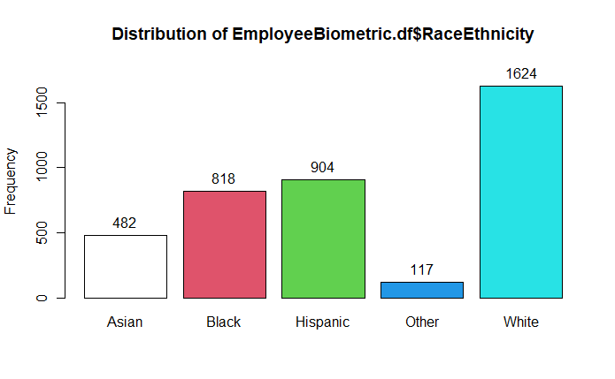

```r
epiDisplay::tab1(EmployeeBiometric.df$RaceEthnicity)
```

```
EmployeeBiometric.df$BMIStatus :
              Frequency   %(NA+)   %(NA-)
Underweight         168      4.3      4.3
Normal Weight      1437     36.4     36.6
Overweight         1114     28.2     28.4
Obese              1206     30.6     30.7
NA's                 20      0.5      0.0
  Total            3945    100.0    100.0
```

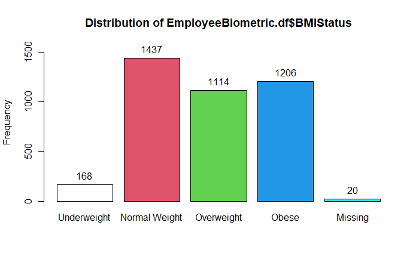

```r
epiDisplay::tab1(EmployeeBiometric.df$BMIStatus)
```

```
EmployeeBiometric.df$Obesity :
          Frequency   %(NA+)   %(NA-)
Not Obese      2719     68.9     69.3
Obese          1206     30.6     30.7
NA's             20      0.5      0.0
  Total        3945    100.0    100.0
```

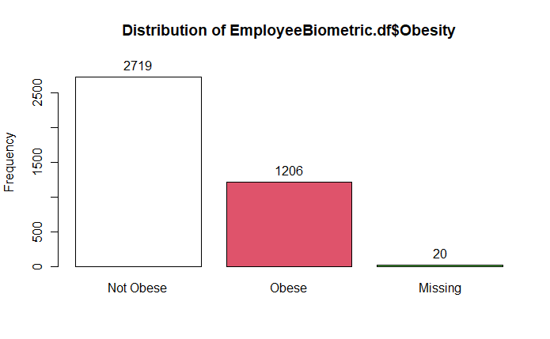

```r
epiDisplay::tab1(EmployeeBiometric.df$Obesity)
```

Create bar plots for numeric variables : AgeYears, TotalCholesterolmgdL, SBPmmHg, DBPmmHg, and the calculated value for BMIMetric

Figures for the EmployeeBiometric.df object variables with numeric values (e.g., often called interval values or scale values) will be displayed in a 2 by 2 graphical grid. Each square in the grid uses a different R-based function to display data distribution: • Histogram — Use the hist() function. • Density Curve — The plot() function is wrapped around the density() function. • Beanplot —Use the beanplot::beanplot() function, by loading the external package beanplot into the active R session. • Quantile-Quantile Curve — Use the qqnorm() function.

## Age Distribution

```r
par(ask=TRUE)
par(mfrow=c(2,2))

hist(EmployeeBiometric.df$AgeYears, main="Age",col="red", breaks=100)


plot(density(EmployeeBiometric.df$AgeYears, na.rm=TRUE),
     main="Age", col="red")
```

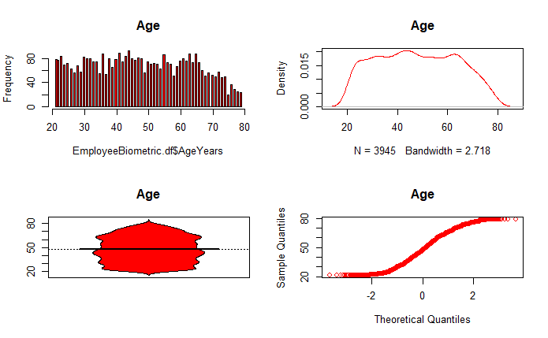

```r
beanplot::beanplot(EmployeeBiometric.df$AgeYears, main="Age", col="red", what=c(0.85,0.85,0.85,0), overallline="mean", boxwex=0.75, horizontal=FALSE)

qqnorm(EmployeeBiometric.df$AgeYears,main="Age",col="red")
```

Variable TotalCholesterolmgl

```r
par(ask=TRUE)
par(mfrow=c(2,2))

hist(EmployeeBiometric.df$TotalCholesterolmgdL, main="Total Cholesterol mg/dL",col="blue", breaks=100)


plot(density(EmployeeBiometric.df$TotalCholesterolmgdL, na.rm=TRUE),
     main="Total Cholesterol mg/dL", col="blue")
```

```r
beanplot::beanplot(EmployeeBiometric.df$TotalCholesterolmgdL, main="Total Cholesterol mg/dL", col="blue", what=c(0.85,0.85,0.85,0), overallline="mean", boxwex=0.75, horizontal=FALSE)
```

```
log="y" selected
```

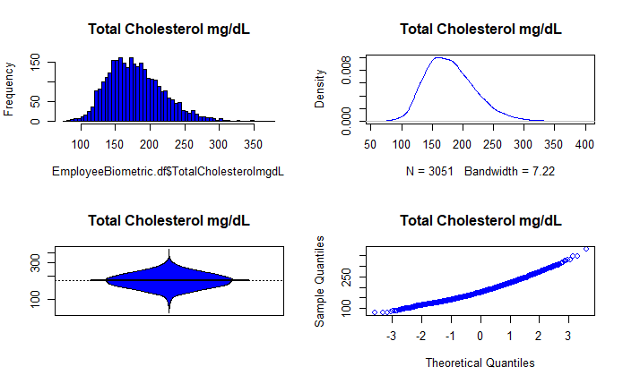

```r
qqnorm(EmployeeBiometric.df$TotalCholesterolmgdL,main="Total Cholesterol mg/dL",col="blue")
```

Variable SBPmmHg

```r
par(ask=TRUE)
par(mfrow=c(2,2))

hist(EmployeeBiometric.df$SBPmmHg,
     main="Systolic Blood Pressure",
     col="blue",
     breaks=100)


plot(density(EmployeeBiometric.df$SBPmmHg,
             na.rm=TRUE),
     main="Systolic Blood PressureL",
     col="blue")
```

```r
beanplot::beanplot(EmployeeBiometric.df$SBPmmHg,
                   main="Systolic Blood Pressure",
                   col="blue",
                   what=c(1,1,1,0),
                   overallline="mean",
                   boxwex=0.75,
                   horizontal=FALSE)
```

```
log="y" selected
```

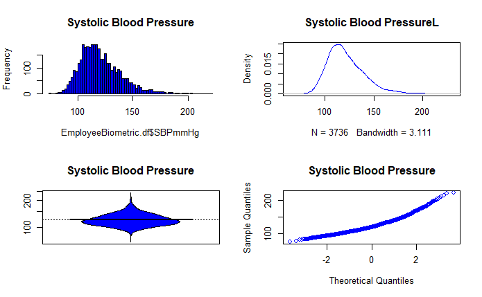

```r
qqnorm(EmployeeBiometric.df$SBPmmHg,
       main="Systolic Blood Pressure",
       col="blue")
```

Variable DBPmmHg

```r
par(ask=TRUE)
par(mfrow=c(2,2))

hist(EmployeeBiometric.df$DBPmmHg, main="Diastolic Blood Pressure",col="green", breaks=100)


plot(density(EmployeeBiometric.df$DBPmmHg, na.rm=TRUE),
     main="Diastolic Blood Pressure", col="green")
```

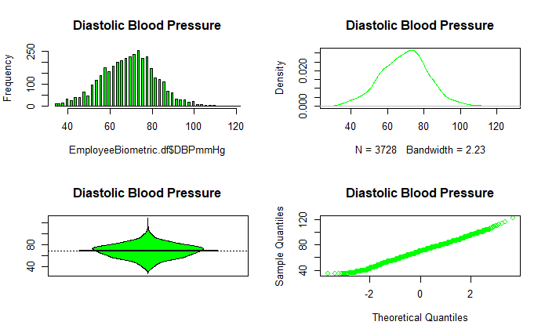

```r
beanplot::beanplot(EmployeeBiometric.df$DBPmmHg, main="Diastolic Blood Pressure", col="green",
                   what=c(0.85,0.85,0.85,0), overallline="mean", boxwex=0.75, horizontal=FALSE)
qqnorm(EmployeeBiometric.df$DBPmmHg,main="Diastolic Blood Pressure",col="green")
```

##Variable BMIMetric

```r
par(ask=TRUE)
par(mfrow=c(2,2))

hist(EmployeeBiometric.df$BMIMetric, main="Body Mass Index: BMI Metric = kg/m^2",col="purple", breaks=200)


plot(density(EmployeeBiometric.df$BMIMetric, na.rm=TRUE),
     main="Body Mass Index: BMI Metric = kg/m^2", col="purple")
```

```r
beanplot::beanplot(EmployeeBiometric.df$BMIMetric, main="Body Mass Index: BMI Metric = kg/m^2", col="purple", what=c(0.85,0.85,0.85,0), overallline="mean", boxwex=0.75, horizontal=FALSE)
```

```
log="y" selected
```

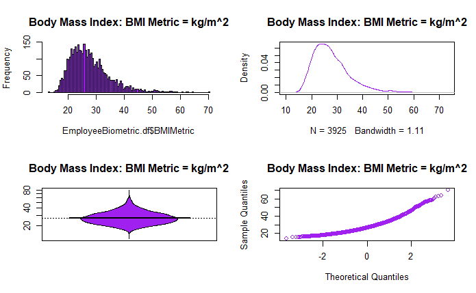

```r
qqnorm(EmployeeBiometric.df$BMIMetric,main="Body Mass Index: BMI Metric = kg/m^2",col="purple")
```

## Summary for variable factors

```r
summary(EmployeeBiometric.df[,c(2,4,9,10)])
```

```
    Gender      RaceEthnicity          BMIStatus         Obesity
 Female:2078   Asian   : 482   Underweight  : 168   Not Obese:2719
 Male  :1867   Black   : 818   Normal Weight:1437   Obese    :1206
               Hispanic: 904   Overweight   :1114   NA's     :  20
               Other   : 117   Obese        :1206
               White   :1624   NA's         :  20
```

## Summary for numeric variable

```r
summary(EmployeeBiometric.df[,c(3,5,7,8)])
```

```
    AgeYears    TotalCholesterolmgdL    DBPmmHg        BMIMetric
 Min.   :21.0   Min.   : 78          Min.   : 34.0   Min.   :13.4
 1st Qu.:34.0   1st Qu.:151          1st Qu.: 60.0   1st Qu.:22.6
 Median :47.0   Median :175          Median : 70.0   Median :26.4
 Mean   :47.7   Mean   :180          Mean   : 69.3   Mean   :27.7
 3rd Qu.:61.0   3rd Qu.:205          3rd Qu.: 78.0   3rd Qu.:31.3
 Max.   :79.0   Max.   :380          Max.   :122.0   Max.   :70.1
                NA's   :894          NA's   :217     NA's   :20
```

Provide percentage of factor variable

```r
epiDisplay::tab1(EmployeeBiometric.df$Gender, graph=FALSE)
```

```
EmployeeBiometric.df$Gender :
        Frequency Percent Cum. percent
Female       2078    52.7         52.7
Male         1867    47.3        100.0
  Total      3945   100.0        100.0
```

```r
epiDisplay::tab1(EmployeeBiometric.df$RaceEthnicity, graph = FALSE)
```

```
EmployeeBiometric.df$RaceEthnicity :
         Frequency Percent Cum. percent
Asian          482    12.2         12.2
Black          818    20.7         33.0
Hispanic       904    22.9         55.9
Other          117     3.0         58.8
White         1624    41.2        100.0
  Total       3945   100.0        100.0
```

```r
epiDisplay::tab1(EmployeeBiometric.df$BMIStatus, graph=FALSE)
```

```
EmployeeBiometric.df$BMIStatus :
              Frequency   %(NA+)   %(NA-)
Underweight         168      4.3      4.3
Normal Weight      1437     36.4     36.6
Overweight         1114     28.2     28.4
Obese              1206     30.6     30.7
NA's                 20      0.5      0.0
  Total            3945    100.0    100.0
```

```r
epiDisplay::tab1(EmployeeBiometric.df$Obesity, graph = FALSE)
```

```
EmployeeBiometric.df$Obesity :
          Frequency   %(NA+)   %(NA-)
Not Obese      2719     68.9     69.3
Obese          1206     30.6     30.7
NA's             20      0.5      0.0
  Total        3945    100.0    100.0
```

# Measures of Central Tendency for Numeric-Type Object Variables

To address this concern and the need for attention to Standard Deviation as a vital descriptive statistic, consider use of the RcmdrMisc::numSummary() function, which by default provides Mean, Standard Deviation, IQR (Interquartile Range, or Q3 minus Q1) Quartiles (0% (Minimum), 25%, 50% (Median), 75%, 100% (Maximum)) N, and NAs (the number of missing values, if any).

```r
RcmdrMisc::numSummary(EmployeeBiometric.df$AgeYears)
```

```
    mean      sd IQR 0% 25% 50% 75% 100%    n
 47.6563 15.8221  27 21  34  47  61   79 3945
```

```r
RcmdrMisc::numSummary(EmployeeBiometric.df$TotalCholesterolmgdL)
```

```
    mean      sd IQR 0% 25% 50% 75% 100%    n  NA
 179.835 39.9184  54 78 151 175 205  380 3051 894
```

```r
RcmdrMisc::numSummary(EmployeeBiometric.df$SBPmmHg)
```

```
    mean      sd IQR 0% 25% 50% 75% 100%    n  NA
 121.646 18.6069  24 74 108 118 132  222 3736 209
```

```r
RcmdrMisc::numSummary(EmployeeBiometric.df$DBPmmHg)
```

```
    mean     sd IQR 0% 25% 50% 75% 100%    n  NA
 69.3192 12.836  18 34  60  70  78  122 3728 217
```

```r
RcmdrMisc::numSummary(EmployeeBiometric.df$BMIMetric)
```

```
    mean      sd  IQR    0%   25%   50%   75%  100%    n NA
 27.7057 7.12103 8.65 13.45 22.61 26.38 31.26 70.08 3925 20
```

Summary, group by gender

```r
RcmdrMisc::numSummary(EmployeeBiometric.df[,c("AgeYears","TotalCholesterolmgdL","SBPmmHg","DBPmmHg","BMIMetric")],groups = Gender)
```

```
Variable: AgeYears
          mean      sd IQR 0% 25% 50% 75% 100%    n NA
Female 47.6925 15.7969  27 21  34  47  61   79 2078  0
Male   47.6160 15.8542  27 21  34  47  61   79 1867  0

Variable: TotalCholesterolmgdL
          mean      sd  IQR 0% 25% 50%   75% 100%    n  NA
Female 179.768 40.5027 56.0 78 150 176 206.0  380 1628 450
Male   179.911 39.2533 52.5 85 151 175 203.5  348 1423 444

Variable: SBPmmHg
          mean      sd IQR 0% 25% 50% 75% 100%    n  NA
Female 119.390 18.0147  20 82 108 116 128  222 1976 102
Male   124.178 18.9374  26 74 110 122 136  220 1760 107

Variable: DBPmmHg
          mean     sd IQR 0% 25% 50% 75% 100%    n  NA
Female 68.2222 12.604  16 34  60  68  76  122 1971 107
Male   70.5498 12.985  18 34  62  72  80  114 1757 110

Variable: BMIMetric
          mean      sd   IQR    0%    25%   50%   75%  100%    n NA
Female 27.6231 7.17061 8.745 15.41 22.435 26.18 31.18 64.15 2067 11
Male   27.7976 7.06625 8.540 13.45 22.750 26.56 31.29 70.08 1858  9
```

Summary, group by RaceEthnicity

```r
RcmdrMisc::numSummary(EmployeeBiometric.df[,c("AgeYears","TotalCholesterolmgdL","SBPmmHg","DBPmmHg","BMIMetric")],groups = RaceEthnicity)
```

```
Variable: AgeYears
            mean      sd IQR 0% 25% 50% 75% 100%    n NA
Asian    47.0353 14.7131  24 21  35  46  59   79  482  0
Black    48.2433 16.1025  28 21  34  49  62   79  818  0
Hispanic 46.8584 15.3455  26 21  35  46  61   79  904  0
Other    38.6068 13.3177  20 21  28  36  48   78  117  0
White    48.6410 16.2003  27 21  35  48  62   79 1624  0

Variable: TotalCholesterolmgdL
            mean      sd   IQR  0% 25%   50%    75% 100%    n  NA
Asian    178.809 40.5190 52.00  95 150 175.0 202.00  324  362 120
Black    181.892 40.7727 54.75  78 152 177.0 206.75  380  646 172
Hispanic 178.557 38.1856 52.50  82 150 174.0 202.50  309  687 217
Other    176.864 38.7806 59.00 109 147 171.5 206.00  292   88  29
White    179.979 40.3126 54.00  82 151 176.0 205.00  347 1268 356

Variable: SBPmmHg
            mean      sd IQR 0% 25% 50% 75% 100%    n NA
Asian    119.062 18.0030  24 82 106 116 130  222  454 28
Black    125.683 18.4081  24 90 112 122 136  200  769 49
Hispanic 122.948 18.4694  22 88 110 120 132  214  863 41
Other    122.000 18.0343  25 90 108 118 133  198  111  6
White    119.635 18.6154  24 74 106 116 130  220 1539 85

Variable: DBPmmHg
            mean      sd IQR 0% 25% 50% 75% 100%    n NA
Asian    67.6380 12.6124  18 38  58  68  76  104  453 29
Black    72.5312 12.9211  16 34  64  74  80  112  768 50
Hispanic 70.5128 13.0697  18 34  62  72  80  122  862 42
Other    68.8649 12.2121  16 34  62  70  78  100  111  6
White    67.5698 12.3939  18 34  58  68  76  116 1534 90

Variable: BMIMetric
            mean      sd     IQR    0%     25%    50%     75%  100%    n NA
Asian    27.9289 7.45770 10.0150 13.45 22.2075 26.325 32.2225 58.34  476  6
Black    27.4193 6.73504  8.0600 15.55 22.8300 26.250 30.8900 64.15  813  5
Hispanic 27.6545 6.99525  8.6675 15.53 22.6600 26.375 31.3275 62.19  902  2
Other    28.5462 6.87024  7.7500 17.57 23.8900 26.690 31.6400 51.24  117  0
White    27.7517 7.29454  8.6200 15.34 22.5100 26.490 31.1300 70.08 1617  7
```

Summary, group by BMIstatus

```r
RcmdrMisc::numSummary(EmployeeBiometric.df[,c("AgeYears","TotalCholesterolmgdL","SBPmmHg","DBPmmHg","BMIMetric")],groups = BMIStatus)
```

```
Variable: AgeYears
                 mean      sd   IQR 0% 25% 50%   75% 100%    n NA
Underweight   45.9583 15.3289 27.25 21  32  46 59.25   77  168  0
Normal Weight 47.7537 15.8668 27.00 21  34  47 61.00   79 1437  0
Overweight    47.9282 15.7987 26.75 21  35  48 61.75   79 1114  0
Obese         47.4677 15.8322 26.75 21  34  47 60.75   79 1206  0

Variable: TotalCholesterolmgdL
                 mean      sd IQR 0%   25%   50%   75% 100%    n  NA
Underweight   179.354 39.8540  48 87 154.5 173.0 202.5  326  127  41
Normal Weight 179.461 41.0036  54 78 150.0 174.0 204.0  380 1088 349
Overweight    181.183 40.0782  56 82 151.0 177.0 207.0  347  871 243
Obese         179.254 38.6444  52 82 151.0 176.5 203.0  324  950 256

Variable: SBPmmHg
                 mean      sd IQR 0% 25% 50% 75% 100%    n NA
Underweight   113.045 18.6707  16 82 102 110 118  208  157 11
Normal Weight 116.622 18.1826  20 76 104 114 124  220 1363 74
Overweight    123.802 18.5569  24 74 110 120 134  222 1058 56
Obese         126.915 17.1579  24 90 114 126 138  204 1145 61

Variable: DBPmmHg
                 mean      sd IQR 0% 25% 50% 75% 100%    n NA
Underweight   63.3758 12.8100  18 36  54  64  72  116  157 11
Normal Weight 65.9750 12.3119  16 34  58  66  74  114 1358 79
Overweight    70.6199 12.5282  16 34  62  72  78  122 1055 59
Obese         72.9817 12.4347  16 34  64  74  80  108 1145 61

Variable: BMIMetric
                 mean       sd    IQR    0%     25%   50%     75%  100%    n NA
Underweight   17.4923 0.824308 1.0325 13.45 17.0900 17.58 18.1225 18.59  168  0
Normal Weight 22.1205 1.747179 2.9300 18.60 20.7200 22.28 23.6500 25.00 1437  0
Overweight    27.3041 1.395345 2.3650 25.00 26.0725 27.24 28.4375 30.00 1114  0
Obese         36.1543 6.022411 6.9200 30.01 31.7400 34.19 38.6600 70.08 1206  0
```

Summary, group by Obesity

```r
RcmdrMisc::numSummary(EmployeeBiometric.df[,c("AgeYears","TotalCholesterolmgdL","SBPmmHg","DBPmmHg","BMIMetric")],groups = Obesity)
```

```
Variable: AgeYears
             mean      sd   IQR 0% 25% 50%   75% 100%    n NA
Not Obese 47.7142 15.8071 27.00 21  34  47 61.00   79 2719  0
Obese     47.4677 15.8322 26.75 21  34  47 60.75   79 1206  0

Variable: TotalCholesterolmgdL
             mean      sd IQR 0% 25%   50% 75% 100%    n  NA
Not Obese 180.174 40.5399  54 78 151 175.0 205  380 2086 633
Obese     179.254 38.6444  52 82 151 176.5 203  324  950 256

Variable: SBPmmHg
             mean      sd IQR 0% 25% 50% 75% 100%    n  NA
Not Obese 119.351 18.7503  22 74 106 116 128  222 2578 141
Obese     126.915 17.1579  24 90 114 126 138  204 1145  61

Variable: DBPmmHg
             mean      sd IQR 0% 25% 50% 75% 100%    n  NA
Not Obese 67.7230 12.6746  18 34  58  68  76  122 2570 149
Obese     72.9817 12.4347  16 34  64  74  80  108 1145  61

Variable: BMIMetric
             mean      sd  IQR    0%    25%   50%    75%  100%    n NA
Not Obese 23.9583 3.37783 5.38 13.45 21.365 24.01 26.745 30.00 2719  0
Obese     36.1543 6.02241 6.92 30.01 31.740 34.19 38.660 70.08 1206  0
```

## 1. Distribution of age based on categorical variables :

```r
par(ask=TRUE)
par(mfrow=c(2,2))

boxplot(AgeYears ~ Gender, data=EmployeeBiometric.df,
        main="Age (Years) by Gender", ylab="Age (Years)",
        cex.axis=1.15, cex.lab=1.15)

beeswarm(AgeYears~Gender, data=EmployeeBiometric.df,
        col=c("red","blue"),add=TRUE,spacing=0.10)
```

```r
boxplot(AgeYears~RaceEthnicity, data=EmployeeBiometric.df,
        main="Age (Years) by Race Ethnicity", ylab="Age (Years)",
        cex.axis=1.15, cex.lab=1.15)
beeswarm(AgeYears~RaceEthnicity, data=EmployeeBiometric.df,
        col=c("red","blue","green","cyan","orange"),add=TRUE,spacing=0.10)
```

```r
boxplot(AgeYears~BMIStatus, data=EmployeeBiometric.df,
        main="Age (Years) by BMI Status", ylab="Age (Years)",
        cex.axis=1.15, cex.lab=1.15)
beeswarm(AgeYears~BMIStatus, data=EmployeeBiometric.df,
        col=c("red","blue","green","black"),add=TRUE,spacing=0.10)
```

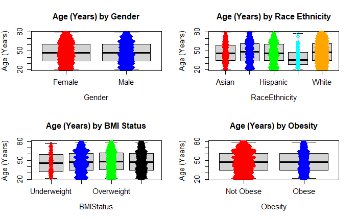

```r
boxplot(AgeYears~Obesity, data=EmployeeBiometric.df,
        main="Age (Years) by Obesity", ylab="Age (Years)",
        cex.axis=1.15, cex.lab=1.15)
beeswarm(AgeYears~Obesity, data= EmployeeBiometric.df,
         col=c("red","blue"), add=TRUE, spacing=0.1)
```

## 2. Distribution of Total Cholesterol based on categorical variables :

```r
par(ask=TRUE)
par(mfrow=c(2,2))

boxplot(TotalCholesterolmgdL ~ Gender, data=EmployeeBiometric.df,
        main="Total Cholesterol by Gender", ylab="Total Cholesterol",
        cex.axis=1.15, cex.lab=1.15)

beeswarm(TotalCholesterolmgdL~Gender, data=EmployeeBiometric.df,
        col=c("red","blue"),add=TRUE,spacing=0.10)
```

```r
boxplot(TotalCholesterolmgdL~RaceEthnicity, data=EmployeeBiometric.df,
        main="Total Cholesterol by Race Ethnicity", ylab="Total Cholesterol",
        cex.axis=1.15, cex.lab=1.15)
beeswarm(TotalCholesterolmgdL~RaceEthnicity, data=EmployeeBiometric.df,
        col=c("red","blue","green","cyan","orange"),add=TRUE,spacing=0.10)
```

```r
boxplot(TotalCholesterolmgdL~BMIStatus, data=EmployeeBiometric.df,
        main="Total Cholesterol by BMI Status", ylab="Total Cholesterol",
        cex.axis=1.15, cex.lab=1.15)
beeswarm(TotalCholesterolmgdL~BMIStatus, data=EmployeeBiometric.df,
        col=c("red","blue","green","black"),add=TRUE,spacing=0.10)
```

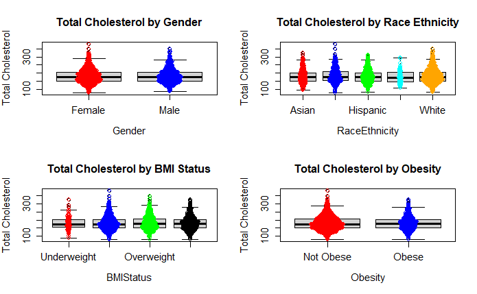

```r
boxplot(TotalCholesterolmgdL~Obesity, data=EmployeeBiometric.df,
        main="Total Cholesterol by Obesity", ylab="Total Cholesterol",
        cex.axis=1.15, cex.lab=1.15)
beeswarm(TotalCholesterolmgdL~Obesity, data= EmployeeBiometric.df,
         col=c("red","blue"), add=TRUE, spacing=0.1)
```

## 3. Distribution of SBP based on categorical variables :

```r
par(ask=TRUE)
par(mfrow=c(2,2))
boxplot(SBPmmHg ~ Gender, data=EmployeeBiometric.df,
        main="Systolic Blood Pressure by Gender", ylab="Systolic Blood Pressure",
        cex.axis=1.15, cex.lab=1.15)

beeswarm(SBPmmHg~Gender, data=EmployeeBiometric.df,
        col=c("red","blue"),add=TRUE,spacing=0.10)
```

```r
boxplot(SBPmmHg~RaceEthnicity, data=EmployeeBiometric.df,
        main="Systolic Blood Pressure by Race Ethnicity", ylab="Systolic Blood Pressure",
        cex.axis=1.15, cex.lab=1.15)
beeswarm(SBPmmHg~RaceEthnicity, data=EmployeeBiometric.df,
        col=c("red","blue","green","cyan","orange"),add=TRUE,spacing=0.10)
```

```r
boxplot(SBPmmHg~BMIStatus, data=EmployeeBiometric.df,
        main="Systolic Blood Pressure by BMI Status", ylab="Systolic Blood Pressure",
        cex.axis=1.15, cex.lab=1.15)
beeswarm(SBPmmHg~BMIStatus, data=EmployeeBiometric.df,
        col=c("red","blue","green","black"),add=TRUE,spacing=0.10)
```

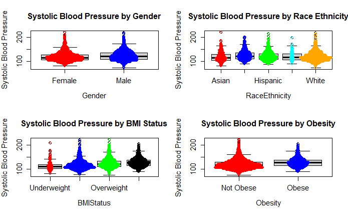

```r
boxplot(SBPmmHg~Obesity, data=EmployeeBiometric.df,
        main="Systolic Blood Pressure by Obesity", ylab="Systolic Blood Pressure",
        cex.axis=1.15, cex.lab=1.15)
beeswarm(SBPmmHg~Obesity, data= EmployeeBiometric.df,
         col=c("red","blue"), add=TRUE, spacing=0.1)
```

4. Distribution of DBP based on categorical variables :

```r
par(ask=TRUE)
par(mfrow=c(2,2))
boxplot(DBPmmHg ~ Gender, data=EmployeeBiometric.df,
        main="Diastolic Blood Pressure by Gender", ylab="Diastolic Blood Pressure",
        cex.axis=1.15, cex.lab=1.15)

beeswarm(DBPmmHg~Gender, data=EmployeeBiometric.df,
        col=c("red","blue"),add=TRUE,spacing=0.10)
```

```r
boxplot(DBPmmHg~RaceEthnicity, data=EmployeeBiometric.df,
        main="Diastolic Blood Pressure by Race Ethnicity", ylab="Diastolic Blood Pressure",
        cex.axis=1.15, cex.lab=1.15)
beeswarm(DBPmmHg~RaceEthnicity, data=EmployeeBiometric.df,
        col=c("red","blue","green","cyan","orange"),add=TRUE,spacing=0.10)
```

```r
boxplot(DBPmmHg~BMIStatus, data=EmployeeBiometric.df,
        main="Diastolic Blood Pressure by BMI Status", ylab="Diastolic Blood Pressuree",
        cex.axis=1.15, cex.lab=1.15)
beeswarm(DBPmmHg~BMIStatus, data=EmployeeBiometric.df,
        col=c("red","blue","green","black"),add=TRUE,spacing=0.10)
```

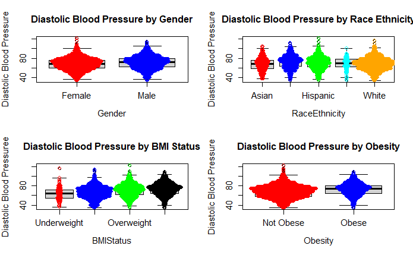

```r
boxplot(DBPmmHg~Obesity, data=EmployeeBiometric.df,
        main="Diastolic Blood Pressure by Obesity", ylab="Diastolic Blood Pressure",
        cex.axis=1.15, cex.lab=1.15)
beeswarm(DBPmmHg~Obesity, data= EmployeeBiometric.df,
         col=c("red","blue"), add=TRUE, spacing=0.1)
```

5. Distribution of BMIMetric by categorical variables

```r
par(ask=TRUE)
par(mfrow=c(2,2))

boxplot(BMIMetric~Gender, data=EmployeeBiometric.df,
        main = "BMIMetric by Gender",
        ylab = "BMI Metric", cex.axis=1.15, cex.lab=1.15)

beeswarm(BMIMetric~Gender, data=EmployeeBiometric.df,
         col = c("red","blue"), add = TRUE, spacing=0.10)
```

```r
boxplot(BMIMetric~RaceEthnicity, data=EmployeeBiometric.df,
        main = "BMIMetric by RaceEthnicity",
        ylab = "BMI Metric", cex.axis=1.15, cex.lab=1.15)
beeswarm(BMIMetric~RaceEthnicity, data=EmployeeBiometric.df,
         col = c("red","blue","green","yellow","cyan"), add = TRUE, spacing=0.10)
```

```r
boxplot(BMIMetric~BMIStatus, data=EmployeeBiometric.df,
        main = "BMIMetric by BMI Status",
        ylab = "BMI Metric", cex.axis=1.15, cex.lab=1.15)
beeswarm(BMIMetric~Gender, data=EmployeeBiometric.df,
         col = c("red","blue","green","yellow"), add = TRUE, spacing=0.10)
```

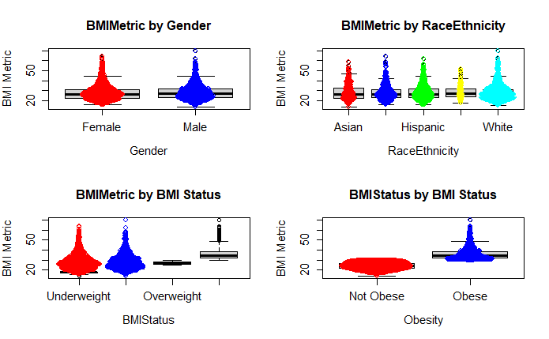

```r
boxplot(BMIMetric~Obesity, data=EmployeeBiometric.df,
        main = "BMIStatus by BMI Status",
        ylab = "BMI Metric", cex.axis=1.15, cex.lab=1.15)
beeswarm(BMIMetric~Obesity, data=EmployeeBiometric.df,
         col = c("red","blue"), add = TRUE, spacing=0.10)
```

## Normality test

```r
shapiro.test((EmployeeBiometric.df$AgeYears))
```

```
    Shapiro-Wilk normality test

data:  (EmployeeBiometric.df$AgeYears)
W = 0.9649, p-value <0.0000000000000002
```

```r
shapiro.test(EmployeeBiometric.df$TotalCholesterolmgdL)
```

```
    Shapiro-Wilk normality test

data:  EmployeeBiometric.df$TotalCholesterolmgdL
W = 0.9783, p-value <0.0000000000000002
```

```r
shapiro.test((EmployeeBiometric.df$SBPmmHg))
```

```
    Shapiro-Wilk normality test

data:  (EmployeeBiometric.df$SBPmmHg)
W = 0.95, p-value <0.0000000000000002
```

```r
shapiro.test(EmployeeBiometric.df$DBPmmHg)
```

```
    Shapiro-Wilk normality test

data:  EmployeeBiometric.df$DBPmmHg
W = 0.9962, p-value = 0.0000000321
```

```r
shapiro.test(EmployeeBiometric.df$BMIMetric)
```

```
    Shapiro-Wilk normality test

data:  EmployeeBiometric.df$BMIMetric
W = 0.9235, p-value <0.0000000000000002
```

Result of Shapiro test distribution : 1. Age = not normal 2. Total cholesterol = not normal 3. SBP = not normal 4. DBP = not normal 5. BMIMetrics = not normal

## Distribution analysis using Q-Q Plot

```r
par(ask=TRUE)
par(mfrow=c(2,3))
qqnorm(EmployeeBiometric.df$AgeYears, col="red",
       main = "Normality of AgeYears-Overall")

qqline(EmployeeBiometric.df$AgeYears, col="blue")
```

```r
qqnorm(EmployeeBiometric.df$TotalCholesterolmgdL, col="red",
       main="Normality of Total Cholesterol - Overal")
qqline(EmployeeBiometric.df$TotalCholesterolmgdL, col="blue")
```

```r
qqnorm(EmployeeBiometric.df$SBPmmHg, col="red",
       main="Normality of SBPmmHg - Overal")
qqline(EmployeeBiometric.df$SBPmmHg, col="blue")
```

```r
qqnorm(EmployeeBiometric.df$DBPmmHg, col="red",
       main="Normality of DBPmmHg - Overal")
qqline(EmployeeBiometric.df$DBPmmHg, col="blue")
```

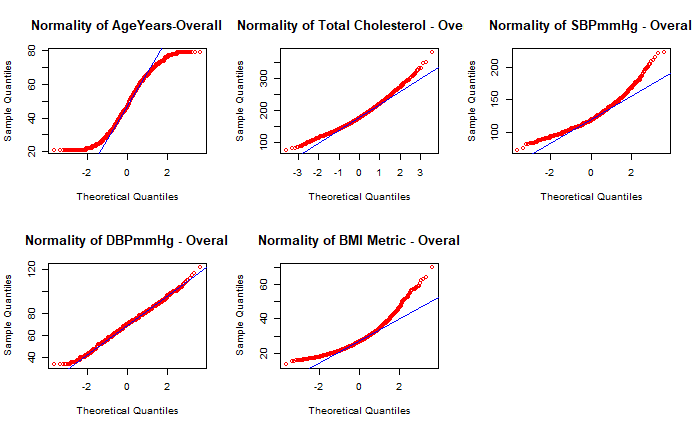

```r
qqnorm(EmployeeBiometric.df$BMIMetric, col="red",
       main="Normality of BMI Metric - Overal")
qqline(EmployeeBiometric.df$BMIMetric, col="blue")
```

As seen in the Q-Q plots provide ample evidence that the numeric object variables AgeYears, TotalCholesterolmgdL, SBPmmHg, DBPmmHg, and BMIMetric do not follow a normal distribution pattern.

The RVAideMemoire::byf.shapiro() function is an excellent choice to examine these questions on normality by breakouts. Observe below how the RVAideMemoire::byf.shapiro() function provides a simple and convenient summary of normality p-values by individual breakouts of the factor-type object variable.

1. Normality test of numeric object variables by Gender

```r
RVAideMemoire::byf.shapiro(AgeYears~Gender,
                           data=EmployeeBiometric.df)
```

```
    Shapiro-Wilk normality tests

data:  AgeYears by Gender

            W               p-value
Female 0.9661 < 0.00000000000000022 ***
Male   0.9633 < 0.00000000000000022 ***
---
Signif. codes:  0 ‘***’ 0.001 ‘**’ 0.01 ‘*’ 0.05 ‘.’ 0.1 ‘ ’ 1
```

```r
RVAideMemoire::byf.shapiro(TotalCholesterolmgdL~Gender,
                           data=EmployeeBiometric.df)
```

```
    Shapiro-Wilk normality tests

data:  TotalCholesterolmgdL by Gender

            W              p-value
Female 0.9806 0.000000000000047433 ***
Male   0.9739 0.000000000000002233 ***
---
Signif. codes:  0 ‘***’ 0.001 ‘**’ 0.01 ‘*’ 0.05 ‘.’ 0.1 ‘ ’ 1
```

```r
RVAideMemoire::byf.shapiro(SBPmmHg ~ Gender,
                           data=EmployeeBiometric.df)
```

```
    Shapiro-Wilk normality tests

data:  SBPmmHg by Gender

            W               p-value
Female 0.9318 < 0.00000000000000022 ***
Male   0.9653 < 0.00000000000000022 ***
---
Signif. codes:  0 ‘***’ 0.001 ‘**’ 0.01 ‘*’ 0.05 ‘.’ 0.1 ‘ ’ 1
```

```r
RVAideMemoire::byf.shapiro(DBPmmHg ~ Gender,
                           data=EmployeeBiometric.df)
```

```
    Shapiro-Wilk normality tests

data:  DBPmmHg by Gender

            W     p-value
Female 0.9945 0.000001046 ***
Male   0.9964   0.0004106 ***
---
Signif. codes:  0 ‘***’ 0.001 ‘**’ 0.01 ‘*’ 0.05 ‘.’ 0.1 ‘ ’ 1
```

```r
RVAideMemoire::byf.shapiro(BMIMetric ~ Gender,
                           data=EmployeeBiometric.df)
```

```
    Shapiro-Wilk normality tests

data:  BMIMetric by Gender

            W               p-value
Female 0.9206 < 0.00000000000000022 ***
Male   0.9259 < 0.00000000000000022 ***
---
Signif. codes:  0 ‘***’ 0.001 ‘**’ 0.01 ‘*’ 0.05 ‘.’ 0.1 ‘ ’ 1
```

2. Normality test of numeric object variables by RaceEthnicity

```r
RVAideMemoire::byf.shapiro(AgeYears ~ RaceEthnicity,
                           data=EmployeeBiometric.df)
```

```
    Shapiro-Wilk normality tests

data:  AgeYears by RaceEthnicity

              W               p-value
Asian    0.9702   0.00000002483267275 ***
Black    0.9616   0.00000000000008035 ***
Hispanic 0.9648   0.00000000000005845 ***
Other    0.9336   0.00002059768431550 ***
White    0.9625 < 0.00000000000000022 ***
---
Signif. codes:  0 ‘***’ 0.001 ‘**’ 0.01 ‘*’ 0.05 ‘.’ 0.1 ‘ ’ 1
```

```r
RVAideMemoire::byf.shapiro(TotalCholesterolmgdL~RaceEthnicity,
                           data=EmployeeBiometric.df)
```

```
    Shapiro-Wilk normality tests

data:  TotalCholesterolmgdL by RaceEthnicity

              W            p-value
Asian    0.9784 0.0000299780295813 ***
Black    0.9757 0.0000000073145531 ***
Hispanic 0.9783 0.0000000149272617 ***
Other    0.9642            0.01574 *
White    0.9777 0.0000000000004407 ***
---
Signif. codes:  0 ‘***’ 0.001 ‘**’ 0.01 ‘*’ 0.05 ‘.’ 0.1 ‘ ’ 1
```

```r
RVAideMemoire::byf.shapiro(SBPmmHg~RaceEthnicity,
                           data=EmployeeBiometric.df)
```

```
    Shapiro-Wilk normality tests

data:  SBPmmHg by RaceEthnicity

              W               p-value
Asian    0.9415   0.00000000000222558 ***
Black    0.9551   0.00000000000001435 ***
Hispanic 0.9462 < 0.00000000000000022 ***
Other    0.9320   0.00002641595847946 ***
White    0.9448 < 0.00000000000000022 ***
---
Signif. codes:  0 ‘***’ 0.001 ‘**’ 0.01 ‘*’ 0.05 ‘.’ 0.1 ‘ ’ 1
```

```r
RVAideMemoire::byf.shapiro(DBPmmHg~RaceEthnicity,
                           data=EmployeeBiometric.df)
```

```
    Shapiro-Wilk normality tests

data:  DBPmmHg by RaceEthnicity

              W   p-value
Asian    0.9939 0.0657746 .
Black    0.9935 0.0020140 **
Hispanic 0.9942 0.0020703 **
Other    0.9736 0.0263387 *
White    0.9961 0.0005367 ***
---
Signif. codes:  0 ‘***’ 0.001 ‘**’ 0.01 ‘*’ 0.05 ‘.’ 0.1 ‘ ’ 1
```

```r
RVAideMemoire::byf.shapiro(BMIMetric~RaceEthnicity,
                           data=EmployeeBiometric.df)
```

```
    Shapiro-Wilk normality tests

data:  BMIMetric by RaceEthnicity

              W               p-value
Asian    0.9373    0.0000000000002847 ***
Black    0.9295 < 0.00000000000000022 ***
Hispanic 0.9266 < 0.00000000000000022 ***
Other    0.9217    0.0000038873197156 ***
White    0.9118 < 0.00000000000000022 ***
---
Signif. codes:  0 ‘***’ 0.001 ‘**’ 0.01 ‘*’ 0.05 ‘.’ 0.1 ‘ ’ 1
```

3. Normality test of numeric object variables by BMIstatus

```r
RVAideMemoire::byf.shapiro(AgeYears~BMIStatus,
                           data=EmployeeBiometric.df)
```

```
    Shapiro-Wilk normality tests

data:  AgeYears by BMIStatus

                   W               p-value
Underweight   0.9526 0.0000193201320965490 ***
Normal Weight 0.9651 < 0.00000000000000022 ***
Overweight    0.9643 0.0000000000000006834 ***
Obese         0.9645 < 0.00000000000000022 ***
---
Signif. codes:  0 ‘***’ 0.001 ‘**’ 0.01 ‘*’ 0.05 ‘.’ 0.1 ‘ ’ 1
```

```r
RVAideMemoire::byf.shapiro(TotalCholesterolmgdL~BMIStatus,
                           data=EmployeeBiometric.df)
```

```
    Shapiro-Wilk normality tests

data:  TotalCholesterolmgdL by BMIStatus

                   W             p-value
Underweight   0.9780             0.03646 *
Normal Weight 0.9710 0.00000000000006071 ***
Overweight    0.9785 0.00000000050969220 ***
Obese         0.9847 0.00000001972027389 ***
---
Signif. codes:  0 ‘***’ 0.001 ‘**’ 0.01 ‘*’ 0.05 ‘.’ 0.1 ‘ ’ 1
```

```r
RVAideMemoire::byf.shapiro(SBPmmHg~BMIStatus,
                           data=EmployeeBiometric.df)
```

```
    Shapiro-Wilk normality tests

data:  SBPmmHg by BMIStatus

                   W               p-value
Underweight   0.8420   0.00000000001006922 ***
Normal Weight 0.9122 < 0.00000000000000022 ***
Overweight    0.9447 < 0.00000000000000022 ***
Obese         0.9702   0.00000000000001384 ***
---
Signif. codes:  0 ‘***’ 0.001 ‘**’ 0.01 ‘*’ 0.05 ‘.’ 0.1 ‘ ’ 1
```

```r
RVAideMemoire::byf.shapiro(DBPmmHg~BMIStatus,
                           data=EmployeeBiometric.df)
```

```
    Shapiro-Wilk normality tests

data:  DBPmmHg by BMIStatus

                   W    p-value
Underweight   0.9792  0.0180324 *
Normal Weight 0.9943 0.00005119 ***
Overweight    0.9947  0.0009071 ***
Obese         0.9944  0.0002697 ***
---
Signif. codes:  0 ‘***’ 0.001 ‘**’ 0.01 ‘*’ 0.05 ‘.’ 0.1 ‘ ’ 1
```

```r
RVAideMemoire::byf.shapiro(BMIMetric~BMIStatus,
                           data=EmployeeBiometric.df)
```

```
    Shapiro-Wilk normality tests

data:  BMIMetric by BMIStatus

                   W               p-value
Underweight   0.9201         0.00000005606 ***
Normal Weight 0.9626 < 0.00000000000000022 ***
Overweight    0.9590 < 0.00000000000000022 ***
Obese         0.8329 < 0.00000000000000022 ***
---
Signif. codes:  0 ‘***’ 0.001 ‘**’ 0.01 ‘*’ 0.05 ‘.’ 0.1 ‘ ’ 1
```

4. Normality test of numeric object variables by Obesity

```r
RVAideMemoire::byf.shapiro(AgeYears~Obesity,
                           data=EmployeeBiometric.df)
```

```
    Shapiro-Wilk normality tests

data:  AgeYears by Obesity

               W               p-value
Not Obese 0.9647 < 0.00000000000000022 ***
Obese     0.9645 < 0.00000000000000022 ***
---
Signif. codes:  0 ‘***’ 0.001 ‘**’ 0.01 ‘*’ 0.05 ‘.’ 0.1 ‘ ’ 1
```

```r
RVAideMemoire::byf.shapiro(TotalCholesterolmgdL~Obesity,
                           data=EmployeeBiometric.df)
```

```
    Shapiro-Wilk normality tests

data:  TotalCholesterolmgdL by Obesity

               W               p-value
Not Obese 0.9754 < 0.00000000000000022 ***
Obese     0.9847         0.00000001972 ***
---
Signif. codes:  0 ‘***’ 0.001 ‘**’ 0.01 ‘*’ 0.05 ‘.’ 0.1 ‘ ’ 1
```

```r
RVAideMemoire::byf.shapiro(SBPmmHg~Obesity,
                           data=EmployeeBiometric.df)
```

```
    Shapiro-Wilk normality tests

data:  SBPmmHg by Obesity

               W               p-value
Not Obese 0.9298 < 0.00000000000000022 ***
Obese     0.9702   0.00000000000001384 ***
---
Signif. codes:  0 ‘***’ 0.001 ‘**’ 0.01 ‘*’ 0.05 ‘.’ 0.1 ‘ ’ 1
```

```r
RVAideMemoire::byf.shapiro(DBPmmHg~Obesity,
                           data=EmployeeBiometric.df)
```

```
    Shapiro-Wilk normality tests

data:  DBPmmHg by Obesity

               W     p-value
Not Obese 0.9953 0.000000308 ***
Obese     0.9944   0.0002697 ***
---
Signif. codes:  0 ‘***’ 0.001 ‘**’ 0.01 ‘*’ 0.05 ‘.’ 0.1 ‘ ’ 1
```

```r
RVAideMemoire::byf.shapiro(BMIMetric~Obesity,
                           data=EmployeeBiometric.df)
```

```
    Shapiro-Wilk normality tests

data:  BMIMetric by Obesity

               W               p-value
Not Obese 0.9789 < 0.00000000000000022 ***
Obese     0.8329 < 0.00000000000000022 ***
---
Signif. codes:  0 ‘***’ 0.001 ‘**’ 0.01 ‘*’ 0.05 ‘.’ 0.1 ‘ ’ 1
```

For additional confirmation, use the ggplot2::ggplot() function to produce QQ plots of the numeric object variables (e.g., AgeYears, TotalCholesterolmgdL, SBPmmHg, DBPmmHg, and BMIMetric) by breakouts of each of the four factor-type object variables (e.g., Gender, RaceEthnicity, BMIStatus, and Obesity)

1.AgeYears

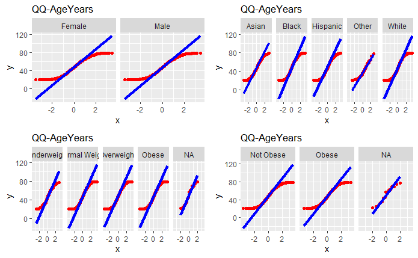

```r
QQAgeYearsbyGender<-ggplot2::ggplot(EmployeeBiometric.df,aes(sample=AgeYears))+
                stat_qq(color="red")+
                stat_qq_line(color="blue", linewidth=1.75)+
                facet_grid(.~Gender)+
                ggtitle("QQ-AgeYears")

QQAgeYearsbyRaceEthnicity<-ggplot2::ggplot(EmployeeBiometric.df,aes(sample=AgeYears))+
                stat_qq(color="red")+
                stat_qq_line(color="blue", linewidth=1.75)+
                facet_grid(.~RaceEthnicity)+
                ggtitle("QQ-AgeYears")

QQAgeYearsbyBMIStatus<-ggplot2::ggplot(EmployeeBiometric.df,aes(sample=AgeYears))+
                stat_qq(color="red")+
                stat_qq_line(color="blue", linewidth=1.75)+
                facet_grid(.~BMIStatus)+
                ggtitle("QQ-AgeYears")

QQAgeYearsbyObesity<-ggplot2::ggplot(EmployeeBiometric.df,aes(sample=AgeYears))+
                stat_qq(color="red")+
                stat_qq_line(color="blue", linewidth=1.75)+
                facet_grid(.~Obesity)+
                ggtitle("QQ-AgeYears")

par(ask=TRUE); gridExtra::grid.arrange(
  QQAgeYearsbyGender,
  QQAgeYearsbyRaceEthnicity,
  QQAgeYearsbyBMIStatus,
  QQAgeYearsbyObesity, ncol=2)
```

```r
NA
```

2. TotalCholesterol

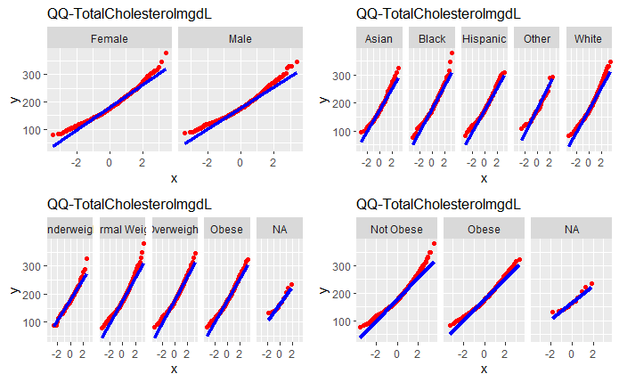

```r
QQTotalCholesterolbyGender<-ggplot2::ggplot(EmployeeBiometric.df,aes(sample=TotalCholesterolmgdL))+
                stat_qq(color="red")+
                stat_qq_line(color="blue", linewidth=1.75)+
                facet_grid(.~Gender)+
                ggtitle("QQ-TotalCholesterolmgdL")

QQTotalCholesterolbyRaceEthnicity<-ggplot2::ggplot(EmployeeBiometric.df,aes(sample=TotalCholesterolmgdL))+
                stat_qq(color="red")+
                stat_qq_line(color="blue", linewidth=1.75)+
                facet_grid(.~RaceEthnicity)+
                ggtitle("QQ-TotalCholesterolmgdL")

QQTotalCholesterolbyBMIStatus<-ggplot2::ggplot(EmployeeBiometric.df,aes(sample=TotalCholesterolmgdL))+
                stat_qq(color="red")+
                stat_qq_line(color="blue", linewidth=1.75)+
                facet_grid(.~BMIStatus)+
                ggtitle("QQ-TotalCholesterolmgdL")

QQTotalCholesterolbyObesity<-ggplot2::ggplot(EmployeeBiometric.df,aes(sample=TotalCholesterolmgdL))+
                stat_qq(color="red")+
                stat_qq_line(color="blue", linewidth=1.75)+
                facet_grid(.~Obesity)+
                ggtitle("QQ-TotalCholesterolmgdL")

par(ask=TRUE); gridExtra::grid.arrange(
  QQTotalCholesterolbyGender,
  QQTotalCholesterolbyRaceEthnicity,
  QQTotalCholesterolbyBMIStatus,
  QQTotalCholesterolbyObesity, ncol=2)
```

```r
NA
```

3. SBPmmHg

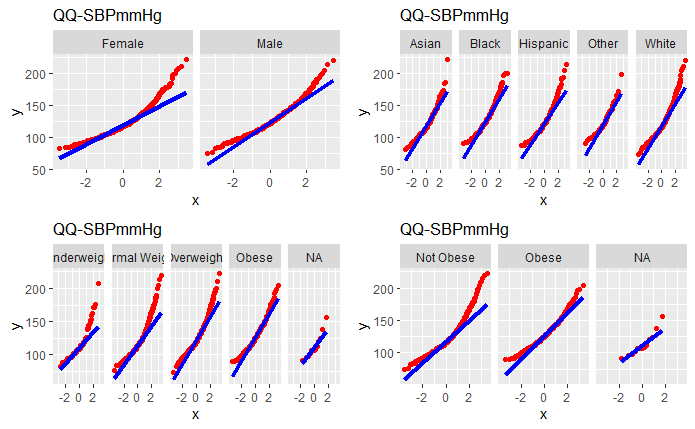

```r
QQSBPbyGender<-ggplot2::ggplot(EmployeeBiometric.df,aes(sample=SBPmmHg))+
                stat_qq(color="red")+
                stat_qq_line(color="blue", linewidth=1.75)+
                facet_grid(.~Gender)+
                ggtitle("QQ-SBPmmHg")

QQSBPbyRaceEthnicity<-ggplot2::ggplot(EmployeeBiometric.df,aes(sample=SBPmmHg))+
                stat_qq(color="red")+
                stat_qq_line(color="blue", linewidth=1.75)+
                facet_grid(.~RaceEthnicity)+
                ggtitle("QQ-SBPmmHg")

QQSBPbyBMIStatus<-ggplot2::ggplot(EmployeeBiometric.df,aes(sample=SBPmmHg))+
                stat_qq(color="red")+
                stat_qq_line(color="blue", linewidth=1.75)+
                facet_grid(.~BMIStatus)+
                ggtitle("QQ-SBPmmHg")

QQSBPbyObesity<-ggplot2::ggplot(EmployeeBiometric.df,aes(sample=SBPmmHg))+
                stat_qq(color="red")+
                stat_qq_line(color="blue", linewidth=1.75)+
                facet_grid(.~Obesity)+
                ggtitle("QQ-SBPmmHg")

par(ask=TRUE); gridExtra::grid.arrange(
  QQSBPbyGender,
  QQSBPbyRaceEthnicity,
  QQSBPbyBMIStatus,
  QQSBPbyObesity, ncol=2)
```

```r
NA
```

4. DBPmmHg

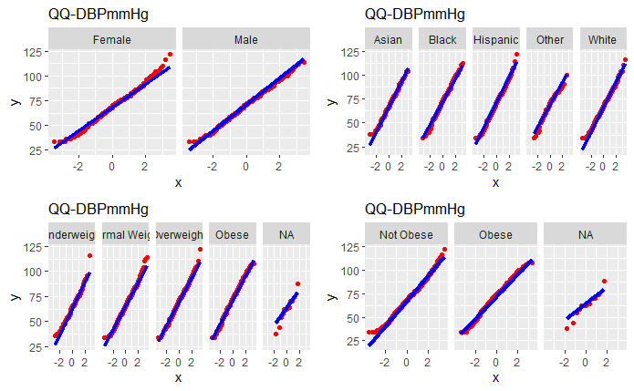

```r
QQDBPbyGender<-ggplot2::ggplot(EmployeeBiometric.df,aes(sample=DBPmmHg))+
                stat_qq(color="red")+
                stat_qq_line(color="blue", linewidth=1.75)+
                facet_grid(.~Gender)+
                ggtitle("QQ-DBPmmHg")

QQDBPbyRaceEthnicity<-ggplot2::ggplot(EmployeeBiometric.df,aes(sample=DBPmmHg))+
                stat_qq(color="red")+
                stat_qq_line(color="blue", linewidth=1.75)+
                facet_grid(.~RaceEthnicity)+
                ggtitle("QQ-DBPmmHg")

QQDBPbyBMIStatus<-ggplot2::ggplot(EmployeeBiometric.df,aes(sample=DBPmmHg))+
                stat_qq(color="red")+
                stat_qq_line(color="blue", linewidth=1.75)+
                facet_grid(.~BMIStatus)+
                ggtitle("QQ-DBPmmHg")

QQDBPbyObesity<-ggplot2::ggplot(EmployeeBiometric.df,aes(sample=DBPmmHg))+
                stat_qq(color="red")+
                stat_qq_line(color="blue", linewidth=1.75)+
                facet_grid(.~Obesity)+
                ggtitle("QQ-DBPmmHg")

par(ask=TRUE); gridExtra::grid.arrange(
  QQDBPbyGender,
  QQDBPbyRaceEthnicity,
  QQDBPbyBMIStatus,
  QQDBPbyObesity, ncol=2)
```

```r
NA
```

5. BMIMetric

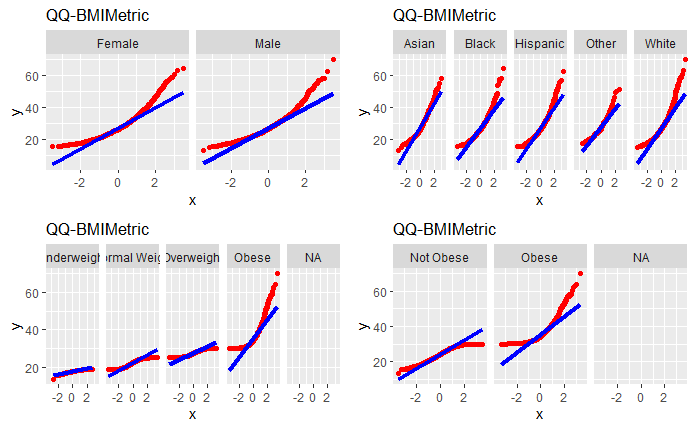

```r
QQBMIMetricbyGender<-ggplot2::ggplot(EmployeeBiometric.df,aes(sample=BMIMetric))+
                stat_qq(color="red")+
                stat_qq_line(color="blue", linewidth=1.75)+
                facet_grid(.~Gender)+
                ggtitle("QQ-BMIMetric")

QQBMIMetricbyRaceEthnicity<-ggplot2::ggplot(EmployeeBiometric.df,aes(sample=BMIMetric))+
                stat_qq(color="red")+
                stat_qq_line(color="blue", linewidth=1.75)+
                facet_grid(.~RaceEthnicity)+
                ggtitle("QQ-BMIMetric")

QQBMIMetricbyBMIStatus<-ggplot2::ggplot(EmployeeBiometric.df,aes(sample=BMIMetric))+
                stat_qq(color="red")+
                stat_qq_line(color="blue", linewidth=1.75)+
                facet_grid(.~BMIStatus)+
                ggtitle("QQ-BMIMetric")

QQBMIMetricbyObesity<-ggplot2::ggplot(EmployeeBiometric.df,aes(sample=BMIMetric))+
                stat_qq(color="red")+
                stat_qq_line(color="blue", linewidth=1.75)+
                facet_grid(.~Obesity)+
                ggtitle("QQ-BMIMetric")

par(ask=TRUE); gridExtra::grid.arrange(
  QQBMIMetricbyGender,
  QQBMIMetricbyRaceEthnicity,
  QQBMIMetricbyBMIStatus,
  QQBMIMetricbyObesity, ncol=2)
```

```r
NA
```

```r
lbsgen <- read.table(file="CPIIISectionLbsGender.csv", header=TRUE, dec=".", sep = ",")
library(asbio)
library(epiDisplay)
asbio::Mode(lbsgen$Lbs)
```

```
[1] 114 122
```

```r
#Frequency Table
par(ask=TRUE)
par(mfrow=c(1,2))
epiDisplay::tab1(lbsgen$Section,
                 main="Fequency Distribution of Section",
                 col=c("red","blue"), font.lab=2, font.axis=2)
```

```
lbsgen$Section :
        Frequency Percent Cum. percent
AM             31    50.8         50.8
PM             30    49.2        100.0
  Total        61   100.0        100.0
```

```
lbsgen$Gender :
        Frequency Percent Cum. percent
Female         35    57.4         57.4
Male           26    42.6        100.0
  Total        61   100.0        100.0
```

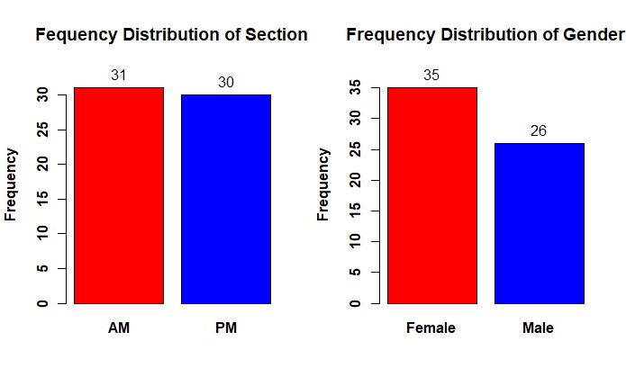

```r
epiDisplay::tab1(lbsgen$Gender, main="Frequency Distribution of Gender", col=c("red", "blue"), font.lab=2, font.axis=2)
```

```r
par(ask=TRUE)
par(mfrow=c(1,2))
epiDisplay::tabpct(lbsgen$Section,
                   lbsgen$Gender, graph = TRUE, decimal=1,
                   main="Frequency Distribution of Section by Gender",
                   xlab="Section", ylab="Gender", cex.axis=1,
                   percent="both", las=1, col = c("red","blue"))
```

```
Original table
              lbsgen$Gender
lbsgen$Section  Female  Male  Total
         AM         15    16     31
         PM         20    10     30
         Total      35    26     61

Row percent
              lbsgen$Gender
lbsgen$Section  Female    Male  Total
            AM      15      16     31
                (48.4)  (51.6)  (100)
            PM      20      10     30
                (66.7)  (33.3)  (100)

Column percent
              lbsgen$Gender
lbsgen$Section  Female       %  Male       %
         AM         15  (42.9)    16  (61.5)
         PM         20  (57.1)    10  (38.5)
         Total      35   (100)    26   (100)
```

```
Original table
             lbsgen$Section
lbsgen$Gender  AM  PM  Total
       Female  15  20     35
       Male    16  10     26
       Total   31  30     61

Row percent
             lbsgen$Section
lbsgen$Gender      AM      PM  Total
       Female      15      20     35
               (42.9)  (57.1)  (100)
       Male        16      10     26
               (61.5)  (38.5)  (100)

Column percent
             lbsgen$Section
lbsgen$Gender  AM       %  PM       %
       Female  15  (48.4)  20  (66.7)
       Male    16  (51.6)  10  (33.3)
       Total   31   (100)  30   (100)
```

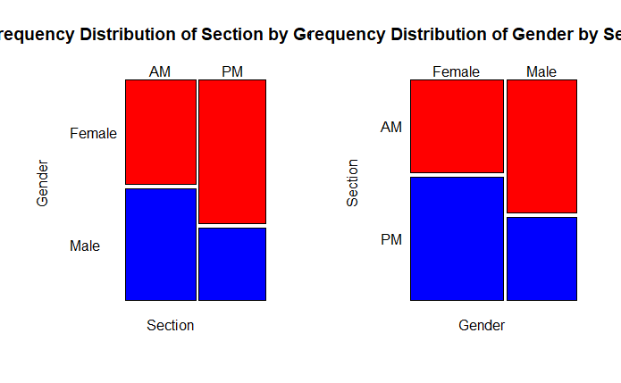

```r
epiDisplay::tabpct(lbsgen$Gender,
                   lbsgen$Section, graph = TRUE, decimal = 1,
                   main="Frequency Distribution of Gender by Section",
                   xlab="Gender", ylab="Section", cex.axis=1,
                   percent="both", las=1, col=c("red","blue"))
```

```r
par(ask=TRUE)
par(mfrow=c(1,2))
epiDisplay::tabpct(EmployeeBiometric.df$RaceEthnicity,
                   EmployeeBiometric.df$Gender, graph = TRUE, decimal=1,
                   main="Frequency Distribution of Race Ethnicity by Gender",
                   xlab="Race Ethnicity", ylab="Gender", cex.axis=1,
                   percent="both", las=1, col = c("cyan","green"))
```

```
Original table
                                  EmployeeBiometric.df$Gender
EmployeeBiometric.df$RaceEthnicity  Female  Male  Total
                          Asian        250   232    482
                          Black        419   399    818
                          Hispanic     484   420    904
                          Other         71    46    117
                          White        854   770   1624
                          Total       2078  1867   3945

Row percent
                                  EmployeeBiometric.df$Gender
EmployeeBiometric.df$RaceEthnicity  Female    Male  Total
                          Asian        250     232    482
                                    (51.9)  (48.1)  (100)
                          Black        419     399    818
                                    (51.2)  (48.8)  (100)
                          Hispanic     484     420    904
                                    (53.5)  (46.5)  (100)
                          Other         71      46    117
                                    (60.7)  (39.3)  (100)
                          White        854     770   1624
                                    (52.6)  (47.4)  (100)

Column percent
                                  EmployeeBiometric.df$Gender
EmployeeBiometric.df$RaceEthnicity  Female       %  Male       %
                          Asian        250  (12.0)   232  (12.4)
                          Black        419  (20.2)   399  (21.4)
                          Hispanic     484  (23.3)   420  (22.5)
                          Other         71   (3.4)    46   (2.5)
                          White        854  (41.1)   770  (41.2)
                          Total       2078   (100)  1867   (100)
```

```
Original table
                           EmployeeBiometric.df$RaceEthnicity
EmployeeBiometric.df$Gender  Asian  Black  Hispanic  Other  White  Total
                     Female    250    419       484     71    854   2078
                     Male      232    399       420     46    770   1867
                     Total     482    818       904    117   1624   3945

Row percent
                           EmployeeBiometric.df$RaceEthnicity
EmployeeBiometric.df$Gender   Asian   Black  Hispanic  Other   White  Total
                     Female     250     419       484     71     854   2078
                               (12)  (20.2)    (23.3)  (3.4)  (41.1)  (100)
                     Male       232     399       420     46     770   1867
                             (12.4)  (21.4)    (22.5)  (2.5)  (41.2)  (100)

Column percent
                           EmployeeBiometric.df$RaceEthnicity
EmployeeBiometric.df$Gender  Asian       %  Black       %  Hispanic       %  Other       %  White       %
                     Female    250  (51.9)    419  (51.2)       484  (53.5)     71  (60.7)    854  (52.6)
                     Male      232  (48.1)    399  (48.8)       420  (46.5)     46  (39.3)    770  (47.4)
                     Total     482   (100)    818   (100)       904   (100)    117   (100)   1624   (100)
```

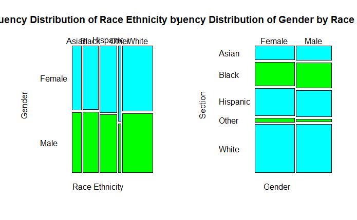

```r
epiDisplay::tabpct(EmployeeBiometric.df$Gender,
                   EmployeeBiometric.df$RaceEthnicity, graph = TRUE, decimal = 1,
                   main="Frequency Distribution of Gender by Race Ethnicity",
                   xlab="Gender", ylab="Section", cex.axis=1,
                   percent="both", las=1, col=c("cyan","green"))
```

```
Original table
                           EmployeeBiometric.df$RaceEthnicity
EmployeeBiometric.df$Gender  Asian  Black  Hispanic  Other  White  Total
                     Female    250    419       484     71    854   2078
                     Male      232    399       420     46    770   1867
                     Total     482    818       904    117   1624   3945

Row percent
                           EmployeeBiometric.df$RaceEthnicity
EmployeeBiometric.df$Gender   Asian   Black  Hispanic  Other   White  Total
                     Female     250     419       484     71     854   2078
                               (12)  (20.2)    (23.3)  (3.4)  (41.1)  (100)
                     Male       232     399       420     46     770   1867
                             (12.4)  (21.4)    (22.5)  (2.5)  (41.2)  (100)

Column percent
                           EmployeeBiometric.df$RaceEthnicity
EmployeeBiometric.df$Gender  Asian       %  Black       %  Hispanic       %  Other       %  White       %
                     Female    250  (51.9)    419  (51.2)       484  (53.5)     71  (60.7)    854  (52.6)
                     Male      232  (48.1)    399  (48.8)       420  (46.5)     46  (39.3)    770  (47.4)
                     Total     482   (100)    818   (100)       904   (100)    117   (100)   1624   (100)
```

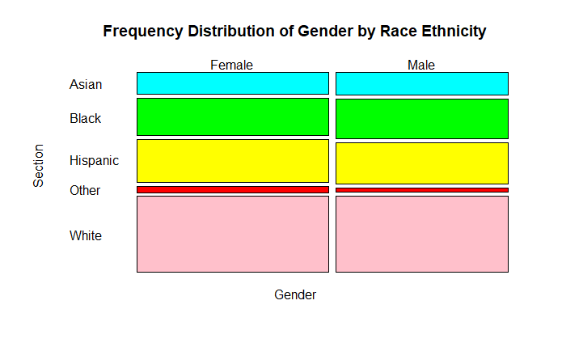

```r
epiDisplay::tabpct(EmployeeBiometric.df$Gender,
                   EmployeeBiometric.df$RaceEthnicity, graph = TRUE, decimal = 1,
                   main="Frequency Distribution of Gender by Race Ethnicity",
                   xlab="Gender", ylab="Section", cex.axis=1,
                   percent="both", las=1, col=c("cyan","green","yellow","red","pink"))
```

```r
par(ask=TRUE)
par(mfrow=c(1,3))
epiDisplay::summ(lbsgen$Lbs, by=NULL,
                 graph=TRUE, box=TRUE, pch=20, ylab="auto", main="Sorted Dotplot of Weight (Lbs), Overall",
                cex.X.axis=1.25,
                cex.Y.axis=1.25,
                font.lab=2, dot.col="auto")
```

```
 obs. mean    median  s.d.   min.   max.
 60   131.733 127     17.589 99     192
```

```r
epiDisplay::summ(lbsgen$Lbs, by=lbsgen$Section,
                 graph=TRUE,
                 pch=20, ylab="auto",
                 main="Sorted Dotplot of Weight (Lbs) by Section",
                 cex.X.axis=1.25,
                 cex.Y.axis=1.25,
                 font.lab=2, dot.col="auto")
```

```
For lbsgen$Section = AM
 obs. mean   median  s.d.   min.   max.
 30   128.3  126     13.152 107    157

For lbsgen$Section = PM
 obs. mean    median  s.d.   min.   max.
 30   135.167 128     20.786 99     192
```

```
For lbsgen$Gender = Female
 obs. mean    median  s.d.   min.   max.
 35   123.971 124     8.28   107    144

For lbsgen$Gender = Male
 obs. mean   median  s.d.   min.   max.
 25   142.6  142     21.274 99     192
```

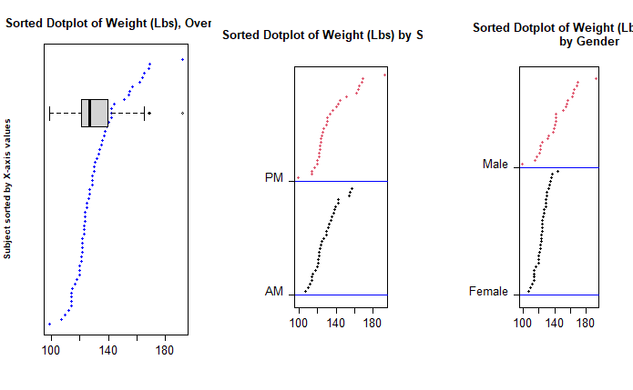

```r
epiDisplay::summ(lbsgen$Lbs, by=lbsgen$Gender,
                 graph=TRUE,
                 pch=20, ylab="auto", main="Sorted Dotplot of Weight (Lbs)
                 by Gender",
                 cex.X.axis=1.25,
                 cex.Y.axis=1.25,
                 font.lab=2,
                 dot.col="auto")
```

```r
library(s20x)
#Create descriptive summaryf or variable Lbs
s20x::summaryStats(lbsgen$Lbs, na.rm=TRUE)
```

```
Minimum value:           99
Maximum value:           192
Mean value:              131.73
Median:                  127
Upper quartile:          139.25
Lower quartile:          121
Variance:                309.39
Standard deviation:      17.59
Midspread (IQR):         18.25
Skewness:                1.08
Number of data values:   61
Number of missing values:   1
```

```r
#Summary stat of Lbs by gender
s20x::summaryStats(Lbs~Gender, lbsgen,
                   na.rm=TRUE)
```

|  | Sample Size | No. Miss. | Mean | Median | Std Dev | Midspread |
| --- | --- | --- | --- | --- | --- | --- |
| Female | 35 | 0 | 123.971 | 124 | 8.27997 | 9 |
| Male | 25 | 1 | 142.600 | 142 | 21.27401 | 32 |

```r
#Summary stat of Lbs by Section
s20x::summaryStats(Lbs~Section, lbsgen,
                   na.rm=TRUE)
```

|  | Sample Size | No. Miss. | Mean | Median | Std Dev | Midspread |
| --- | --- | --- | --- | --- | --- | --- |
| AM | 30 | 1 | 128.300 | 126 | 13.1520 | 16.25 |
| PM | 30 | 0 | 135.167 | 128 | 20.7864 | 21.25 |

```
Row Proportions
         99  107  110  112  114  115  117  118  120  121  122  123  124  125  126  127  129  130  131  132  133  134  135  136  137  138  139  140  142  144  151  154
Female 0.00 0.03 0.03 0.03 0.11 0.00 0.03 0.00 0.09 0.03 0.06 0.09 0.09 0.03 0.03 0.06 0.09 0.06 0.00 0.00 0.03 0.03 0.03 0.03 0.03 0.00 0.00 0.00 0.00 0.03 0.00 0.00
Male   0.04 0.00 0.00 0.00 0.00 0.04 0.00 0.04 0.00 0.04 0.08 0.00 0.00 0.04 0.00 0.00 0.00 0.00 0.04 0.04 0.00 0.00 0.00 0.00 0.00 0.04 0.04 0.04 0.12 0.00 0.04 0.04
        155  157  162  164  165  168  169  192 Totals  n
Female 0.00 0.00 0.00 0.00 0.00 0.00 0.00 0.00      1 35
Male   0.04 0.04 0.04 0.04 0.04 0.04 0.04 0.04      1 25
```

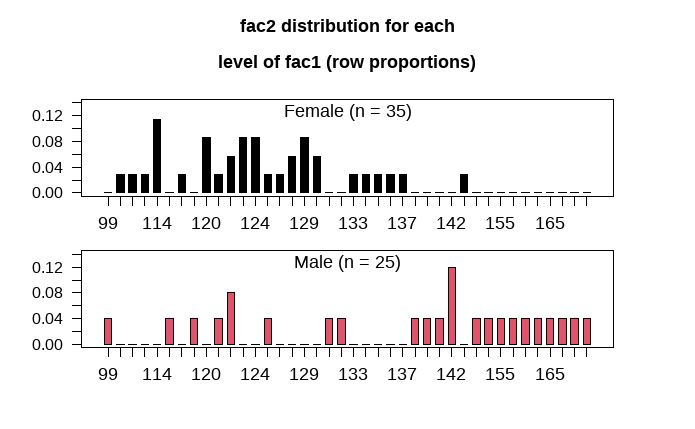

```r
#Creating distribution list of Lbs by Gender
par(ask=TRUE); s20x::rowdistr(crosstablist = xtabs(~Gender + Lbs, data = lbsgen),
               plot = TRUE,
               suppressText = FALSE,
               comp = 'basic')
```

```
Row Proportions
     99  107  110  112  114  115  117  118  120  121  122  123  124  125  126  127  129  130  131  132  133  134  135  136  137  138  139  140  142  144  151  154  155
AM 0.00 0.03 0.03 0.03 0.07 0.03 0.00 0.03 0.03 0.07 0.07 0.03 0.03 0.03 0.00 0.03 0.07 0.00 0.03 0.03 0.00 0.03 0.03 0.00 0.03 0.03 0.03 0.00 0.07 0.00 0.00 0.03 0.03
PM 0.03 0.00 0.00 0.00 0.07 0.00 0.03 0.00 0.07 0.00 0.07 0.07 0.07 0.03 0.03 0.03 0.03 0.07 0.00 0.00 0.03 0.00 0.00 0.03 0.00 0.00 0.00 0.03 0.03 0.03 0.03 0.00 0.00
    157  162  164  165  168  169  192 Totals  n
AM 0.03 0.00 0.00 0.00 0.00 0.00 0.00      1 30
PM 0.00 0.03 0.03 0.03 0.03 0.03 0.03      1 30
```

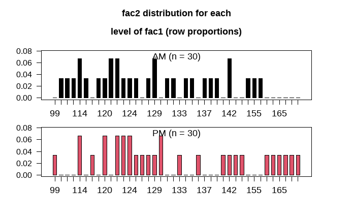

```r
#Creating distribution list of Lbs by Section
par(ask=TRUE); s20x::rowdistr(crosstablist = xtabs(~Section + Lbs, data = lbsgen),
               plot = TRUE,
               suppressText = FALSE,
               comp = 'basic')
```

```r
library(arsenal)
```

```r
#Summary of descriptive statistics
summary(arsenal::tableby(list(Section, Gender)~Lbs,
                         data=lbsgen), text=TRUE, total=TRUE)
```

|  | AM (N=31) | PM (N=30) | Total (N=61) | p value |
| --- | --- | --- | --- | --- |
| Lbs |  |  |  | 0.132 |
| - N-Miss | 1 | 0 | 1 |  |
| - Mean (SD) | 128.300 (13.152) | 135.167 (20.786) | 131.733 (17.589) |  |
| - Range | 107.000 - 157.000 | 99.000 - 192.000 | 99.000 - 192.000 |  |

|  | Female (N=35) | Male (N=26) | Total (N=61) | p value |
| --- | --- | --- | --- | --- |
| Lbs |  |  |  | < 0.001 |
| - N-Miss | 0 | 1 | 1 |  |
| - Mean (SD) | 123.971 (8.280) | 142.600 (21.274) | 131.733 (17.589) |  |
| - Range | 107.000 - 144.000 | 99.000 - 192.000 | 99.000 - 192.000 |  |

```
NA
```

```r
#Pivot table for Gender (rows) and Section (column)
library(pivottabler)

pivottabler::qpvt(lbsgen,"Gender","Section",
                  c("Mean Lbs"="mean(Lbs, na.rm=TRUE)",
                    "SD Lbs"="sd(Lbs, na.rm=TRUE)"),
                  formats=list("%.0f","%.1f"))
```

```
        AM                PM                Total
        Mean Lbs  SD Lbs  Mean Lbs  SD Lbs  Mean Lbs  SD Lbs
Female       122     9.5       125     7.3       124     8.3
Male         134    13.9       155    24.7       143    21.3
Total        128    13.2       135    20.8       132    17.6
```

```r
pivottabler::qpvt(lbsgen,"Section","Gender",
                  c("Mean Lbs"="mean(Lbs, na.rm=TRUE)",
                    "SD Lbs"="sd(Lbs, na.rm=TRUE)"),
                  formats=list("%.0f","%.1f"))
```

```
       Female            Male              Total
       Mean Lbs  SD Lbs  Mean Lbs  SD Lbs  Mean Lbs  SD Lbs
AM          122     9.5       134    13.9       128    13.2
PM          125     7.3       155    24.7       135    20.8
Total       124     8.3       143    21.3       132    17.6
```

```r
pivottabler::qpvt(EmployeeBiometric.df,"RaceEthnicity","Gender",
                  c("Mean SBP"="mean(SBPmmHg, na.rm=TRUE)",
                    "SD SBP"="sd(SBPmmHg, na.rm=TRUE)"),
                  formats=list("%.0f","%.1f"))
```

```
          Female            Male              Total
          Mean SBP  SD SBP  Mean SBP  SD SBP  Mean SBP  SD SBP
Asian          119    18.2       119    17.8       119    18.0
Black          120    17.5       132    17.2       126    18.4
Hispanic       120    18.2       126    18.4       123    18.5
Other          123    19.1       121    16.3       122    18.0
White          119    18.0       121    19.2       120    18.6
Total          119    18.0       124    18.9       122    18.6
```

```r
# Set the seed
base::set.seed(8)
# Data with Normal Distribution Patterns
SBPNormal <- stats::rnorm(100000, mean=120, sd=06)

# Data That Do Not Exhibit Normal Distribution Patterns
SBPNotNormal <- stats::runif(100000, min=102, max=138)
```

# Exploratory Data Analysis

```r
base::getwd()
```

```
[1] "C:/Users/linan/Documents/GitHub/project/R-project/using-r-for-biostatistics"
```

```r
base::ls()
```

```
 [1] "EmployeeBiometric.df"              "lbsgen"                            "QQAgeYearsbyBMIStatus"             "QQAgeYearsbyGender"
 [5] "QQAgeYearsbyObesity"               "QQAgeYearsbyRaceEthnicity"         "QQBMIMetricbyBMIStatus"            "QQBMIMetricbyGender"
 [9] "QQBMIMetricbyObesity"              "QQBMIMetricbyRaceEthnicity"        "QQDBPbyBMIStatus"                  "QQDBPbyGender"
[13] "QQDBPbyObesity"                    "QQDBPbyRaceEthnicity"              "QQSBPbyBMIStatus"                  "QQSBPbyGender"
[17] "QQSBPbyObesity"                    "QQSBPbyRaceEthnicity"              "QQTotalCholesterolbyBMIStatus"     "QQTotalCholesterolbyGender"
[21] "QQTotalCholesterolbyObesity"       "QQTotalCholesterolbyRaceEthnicity" "SBPNormal"                         "SBPNotNormal"
```

```r
utils::str(SBPNormal)
```

```
 num [1:100000] 119 125 117 117 124 ...
```

```r
utils::head(SBPNormal, n=10) # Show the head, first 10 cases
```

```
 [1] 119.492 125.042 117.219 116.695 124.416 119.353 118.978 113.470 101.934 116.441
```

```r
utils::tail(SBPNormal, n=10) # Show the tail, last 10 cases
```

```
 [1] 123.309 116.203 120.248 122.950 115.576 122.086 114.251 113.029 128.144 130.011
```

```r
base::summary(SBPNormal)
```

```
   Min. 1st Qu.  Median    Mean 3rd Qu.    Max.
   94.6   116.0   120.0   120.0   124.1   143.6
```

```r
# Summary statistics
utils::str(SBPNotNormal) # Identify structure
```

```
 num [1:100000] 114 111 120 137 129 ...
```

```r
utils::head(SBPNotNormal, n=10) # Show the head, first 10 cases
```

```
 [1] 113.562 110.940 120.247 136.714 128.528 110.294 118.809 104.221 135.889 120.197
```

```r
utils::tail(SBPNotNormal, n=10) # Show the tail, last 10 cases
```

```
 [1] 109.066 116.185 114.395 127.216 121.895 137.712 103.724 105.628 110.198 118.988
```

```r
base::summary(SBPNotNormal)# Summary statistics
```

```
   Min. 1st Qu.  Median    Mean 3rd Qu.    Max.
    102     111     120     120     129     138
```

```r
par(ask=TRUE)
par(mfrow=c(2,2)) # Pause # 4 figures - 2 rows by 2 column grid
graphics::hist(SBPNormal)

graphics::plot(stats::density(SBPNormal, na.rm=TRUE))
```

```r
graphics::boxplot(SBPNormal)
stats::qqnorm(SBPNormal);
```

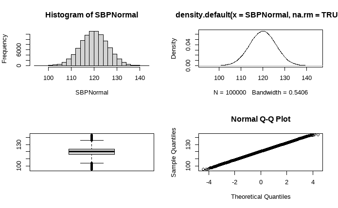

```r
stats::qqline(SBPNormal)
```

```r
par(ask=TRUE)
par(mfrow=c(2,2))
graphics::hist(SBPNotNormal)

graphics::plot(stats::density(SBPNotNormal, na.rm=TRUE))
```

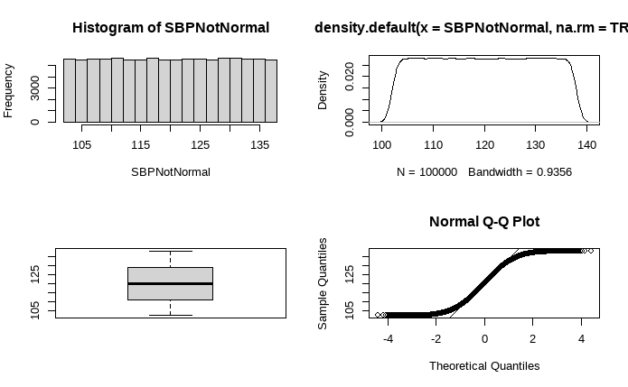

```r
graphics::boxplot(SBPNotNormal)
stats::qqnorm(SBPNotNormal); stats::qqline(SBPNotNormal)
```

Histogram check

```r
par(ask=TRUE)
par(mfrow=c(1,2))
graphics::hist(SBPNormal,
               main="SBP-Normal Distribution",
               col="red",
               breaks=50,
               font.lab=2,
               xlim=c(0,200),
               ylim=c(0,7000))
               axis(side=1, font=2)
               axis(side = 2, font=2)
```

```r
graphics::hist(SBPNotNormal,
               main="SBP - Not Normal Distribution",
               col="red",# Add color
               breaks=50,
               font.lab=2,# Increase granularity of histogram # Bold labels
               xlim=c(0,200), # X axis scale
               ylim=c(0,7000)) # Y axis scale
axis(side=1, font=2) # X axis bold
```

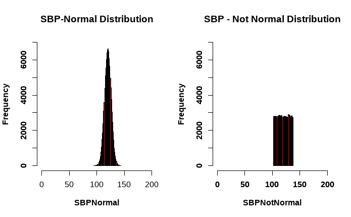

```r
axis(side=2, font=2) # Y axis bold
```

```r
# Notice how both histograms have the same X axis scale # and Y axis scale, allowing meaningful side-by-side # comparisons.
```

```r
# Density Plot par(ask=TRUE)
par(mfrow=c(1,2)) # 2 figures - 1 row by 2 column grid
graphics::plot(stats::density(SBPNormal, na.rm=TRUE),
               main="SBP - Normal Distribution",
               col="red", # Add color
               lwd=5, # Thick line
               font.lab=2,
               xlim=c(0,200),
               ylim=c(0,0.08))
               axis(side=1, font=2)
```

```r
               axis(side=2, font=2)
graphics::plot(stats::density(SBPNotNormal, na.rm=TRUE),
               main="SBP - Not Normal Distribution", col="red",# Add color
               lwd=5,
               font.lab=2,
               xlim=c(0,200),
               ylim=c(0,0.08))
```

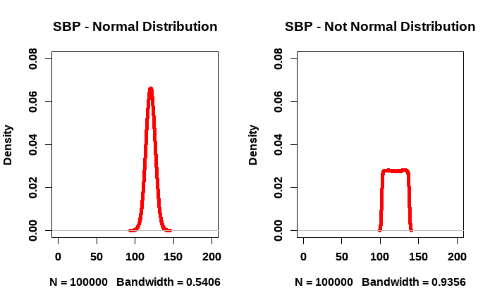

```r
axis(side=1, font=2) # X axis bold
axis(side=2, font=2)
```

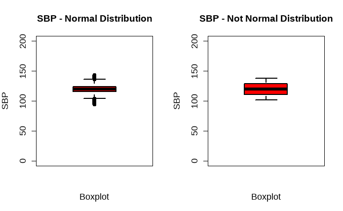

```r
# Boxplot
par(ask=TRUE) # Pause
par(mfrow=c(1,2)) # 2 figures - 1 row by 2 column grid
graphics::boxplot(SBPNormal,
                  main="SBP - Normal Distribution",
                  xlab="Boxplot",
                  ylab="SBP",cex.axis=1.15,
                  cex.lab=1.15,
                  col="red",
                  lwd=2,
                  font.lab=2,
                  font=2,
                  ylim=c(0,200))


graphics::boxplot(SBPNotNormal,
                  main="SBP - Not Normal Distribution",
                  xlab="Boxplot",
                  ylab="SBP",
                  cex.axis=1.15,
                  cex.lab=1.15,
                  col="red",
                  lwd=2,
                  font.lab=2, font=2,
                  ylim=c(0,200))
```

QQ Plot

```r
# Q-Q Plot
par(ask=TRUE)# Pause
par(mfrow=c(1,2)) # 2 figures - 1 row by 2 column grid
stats::qqnorm(SBPNormal,
              main="Q-Q Plot (Blue) and Q-Q Line (Red) of SBP Normal Distribution",
              col="blue",
              xlim=c(-4,4),
              ylim=c(0,200),
              font.axis=2,
              font.lab=2)

stats::qqline(SBPNormal, # Add a Q-Q Line to the Q-Q Plot
              col="red",
              lwd=4,
              lty=2)
```

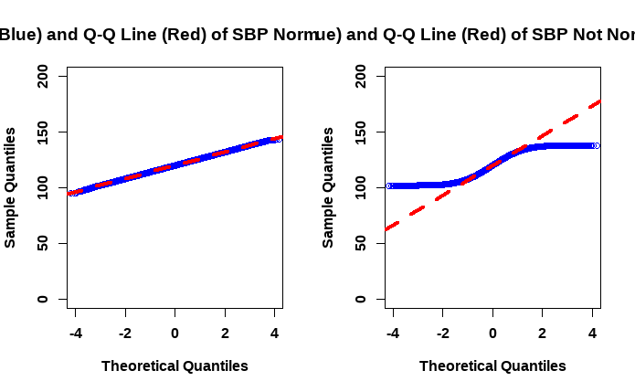

```r
stats::qqnorm(SBPNotNormal, main="Q-Q Plot (Blue) and Q-Q Line (Red) of SBP Not Normal Distribution",
              col="blue",
              xlim=c(-4,4),
              ylim=c(0,200),
              font.axis=2,
              font.lab=2)

stats::qqline(SBPNotNormal,#
              col="red",
              lwd=4,
              lty=2)
```